# Bayesian Learning - Assignment 3

# 4. Bayesian Clustering.

### 4.1 Bayesian estimation of a finite mixture of distributions.

The goal of this step is to explore more in depth the dataset with the focus on the final goal of the project: Bayesian Classification. With this in mind, we have decided to use the Finite Mixture of Gaussians to find clusters, and with them patterns, in our data. We chose a mixture of gaussians because, despite our data is always positive, we saw in the Descriptive Analysis that there is almost no data with values near zero and therefore there is not an abrupt boundary. The observed distributions are more or less bell-shaped with the tails not approaching zero. We could have chosen a mixture of Gammas to adapt to the positiveness of our data, but we decided this complication would not have added much.

Given that we are using this clustering algorithm to learn about the dataset and perform the classification step in a more successful way, we will use the same attributes that will be used for classification: Principal Components 1, 2 and 3. They have been chosen because they gather most of the variance and because when using a higher number of attributes these iterative algorithms took hours to converge.

Since this will become a classification problem and the output class is known, the number of distributions in the final mixture is known: $K = 4$. However, we will also explore $K = 2$ to see if we can discriminate between Goalkeepers and outfield players, and $K = 3$ to separate Goalkeepers, defensive players and offensive players. Then, we do not need to spend resources in choosing the right prior for this parameter. In all cases, since the number of components is fixed, Gibbs sampling is used as MCMC algorithm for model approximation.

In the case of $\mu$ and $\sum$, $\mu$ follows a gaussian prior and $\sum$ (the covariance matrix) follows a Wishart distribution; a generalized gamma distribution to multiple dimensions.

Finally, it is usually assumed that the mixture weights ($\omega$) follow a Dirichlet prior (Dirichlet distributions are the conjugate priors of categorial and multinomial distributions).

##### K = 4.

```r
set.seed(0)

Prior.4 <- list(priorK = "fixed", Kmax = 4)

# Run an MCMC algorithm to obtain a sample from the posterior.
fit.4 <- NMixMCMC(y0 = fifa.x.pca, prior = Prior.4, nMCMC = nMCMC,
                  scale = list(shift=0, scale=1), PED = F)
```

```
##
## Chain number 1
## ==============
## MCMC sampling started on Sat Mar 30 23:12:39 2019.
## Burn-in iteration 10002000300040005000
## Iteration 6000700080009000100001100012000130001400015000
## MCMC sampling finished on Sat Mar 30 23:16:58 2019.
```

*Check for convergence.*

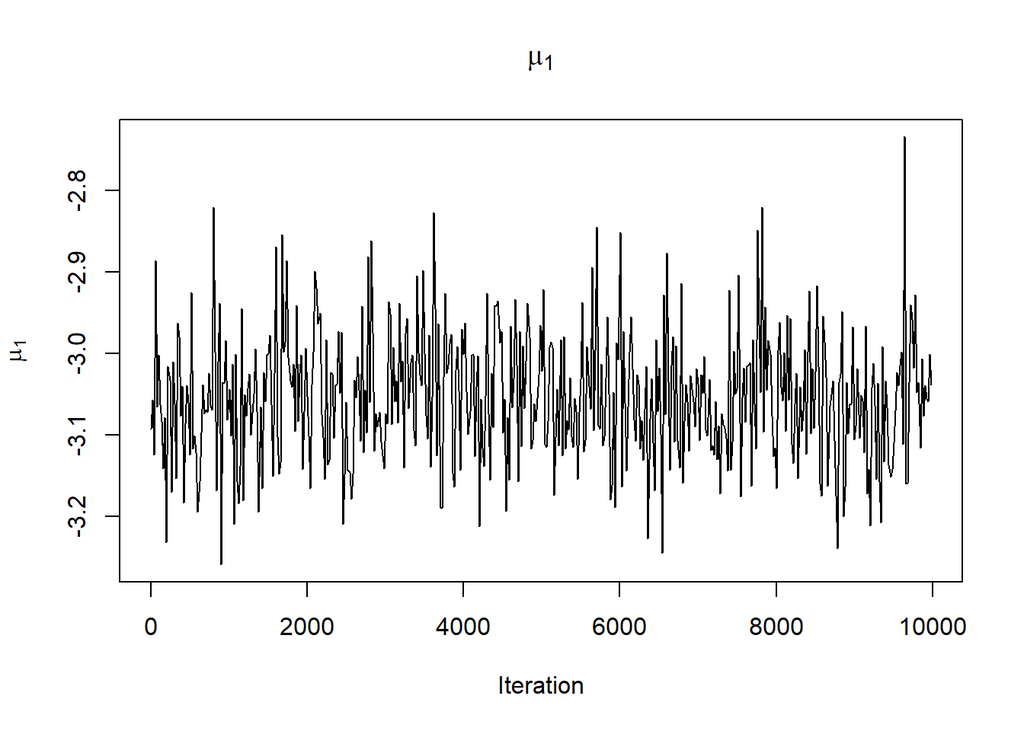

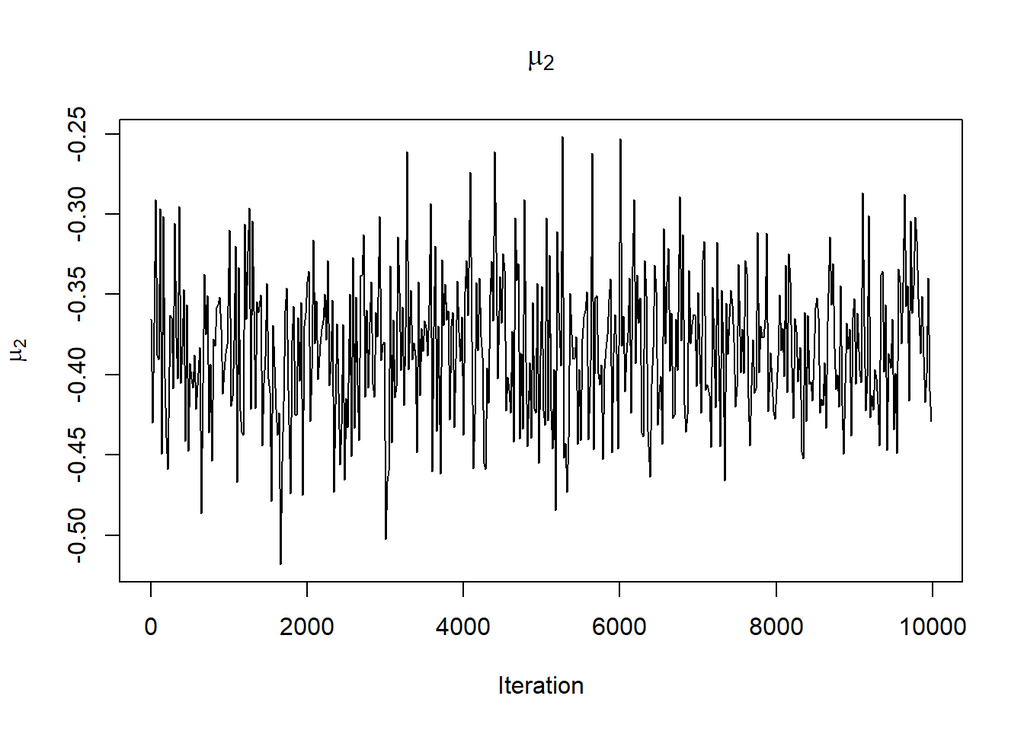

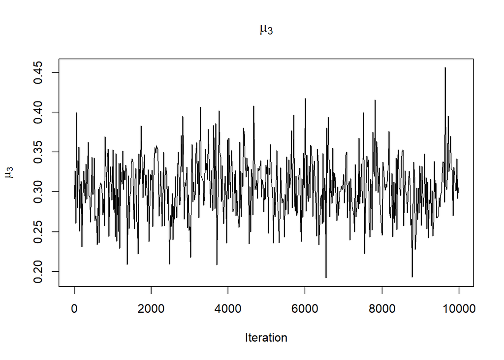

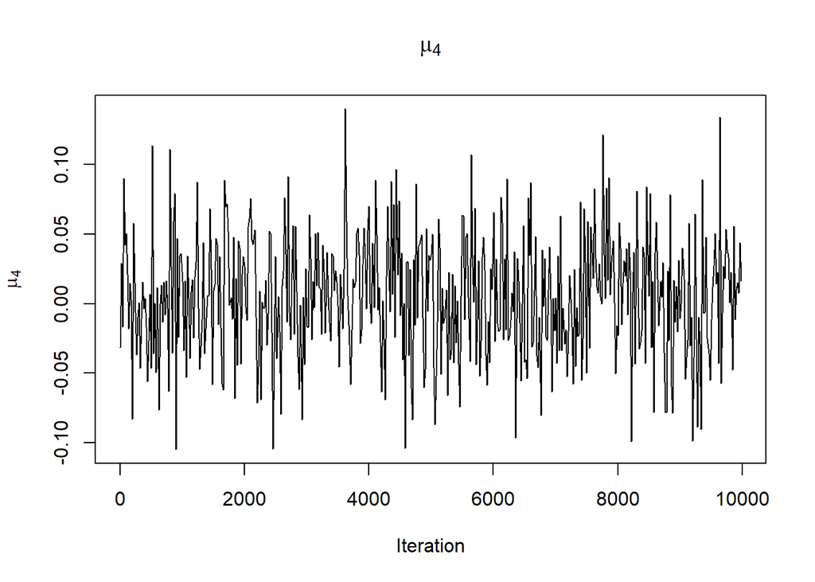

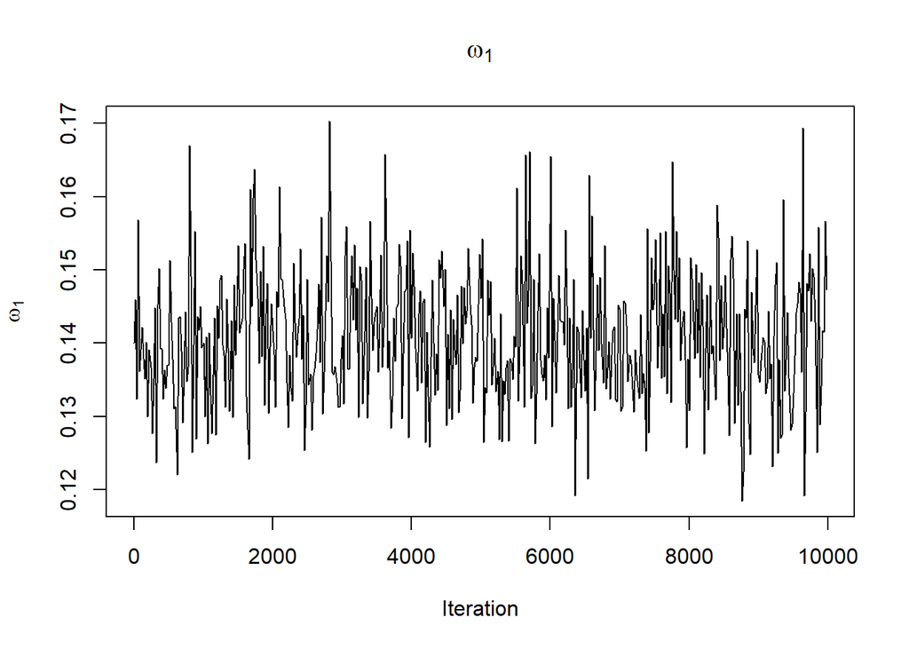

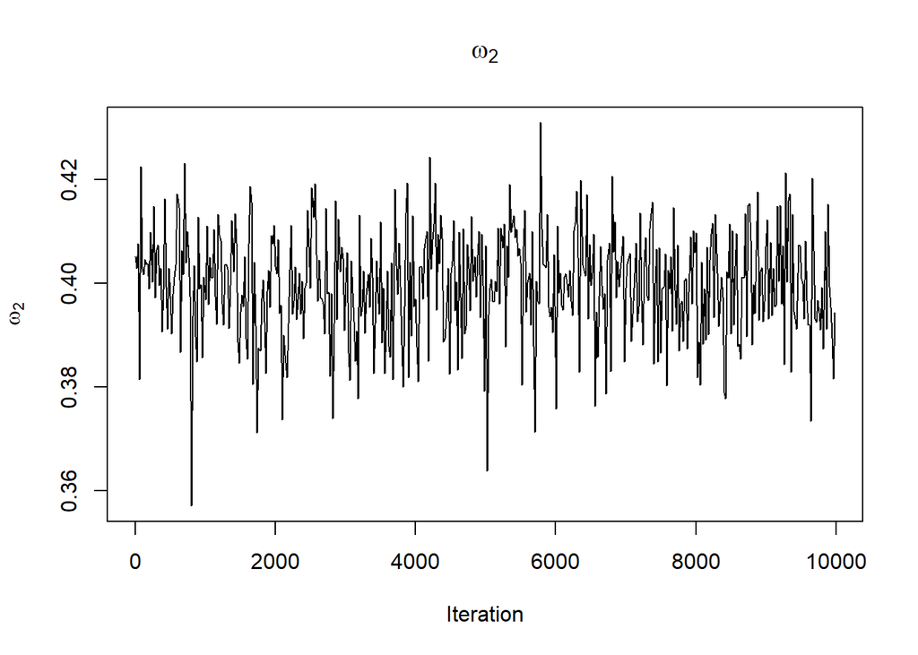

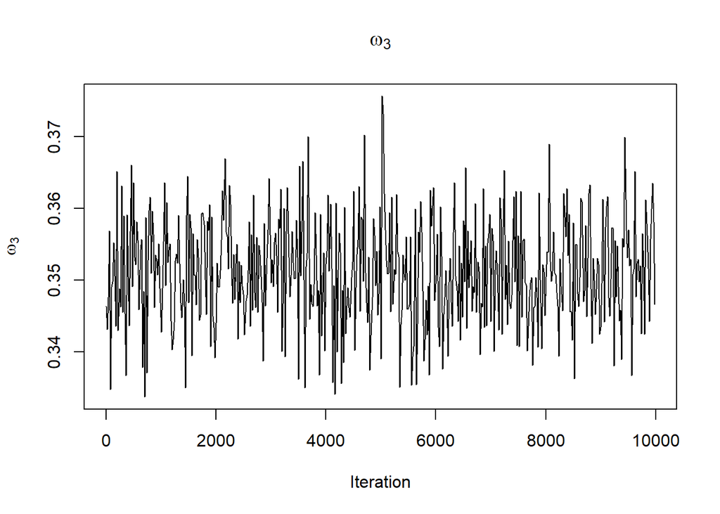

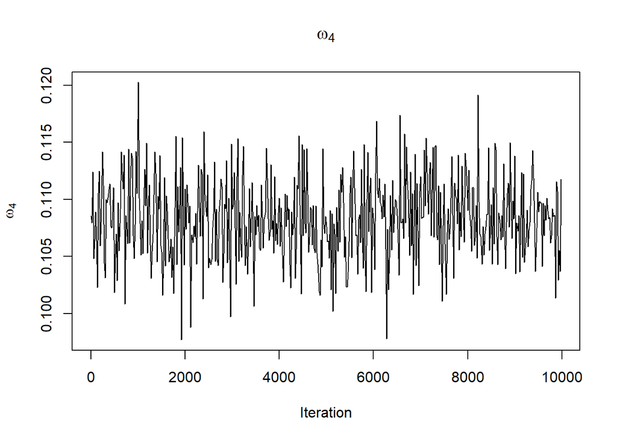

We have used 10000 iterations (after burning 5000). In the convergence plot, we see how most of the parameters $\mu$ and $\omega$ oscillate. However, these oscillation are in a small range of values and when using more iterations (we have checked with 20000 and 30000) they do not disappear.

We are not plotting here how $K$ varies since it is fixed. Also, the parameters of the covariance matrix are also optimized through the iterations, but it is difficult to visualize them in a 2D report. We have observed that they exhibit a similar behaviour as that of $\mu$ and $\omega$.

We will now plot the distributions in 1D (univariate) and in 2D (bivariate).

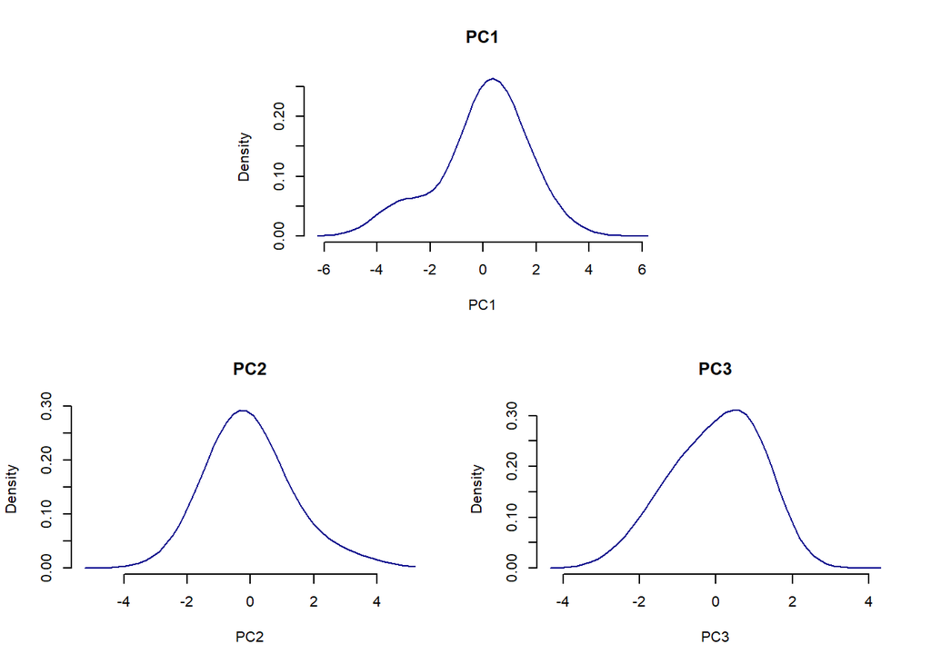

```r
# Plot univariate mixtures
pdens1.4 <- NMixPredDensMarg(fit.4, lgrid=50)
plot(pdens1.4, main=predictors, xlab=predictors)
```

For the first Principal Component the distribution is somehow bimodal, but not for the other Principal Components (recall that this component is related to the physical abilities and the height). With the 1-dimensional plots alone, the clusters are not clearly differenciated.

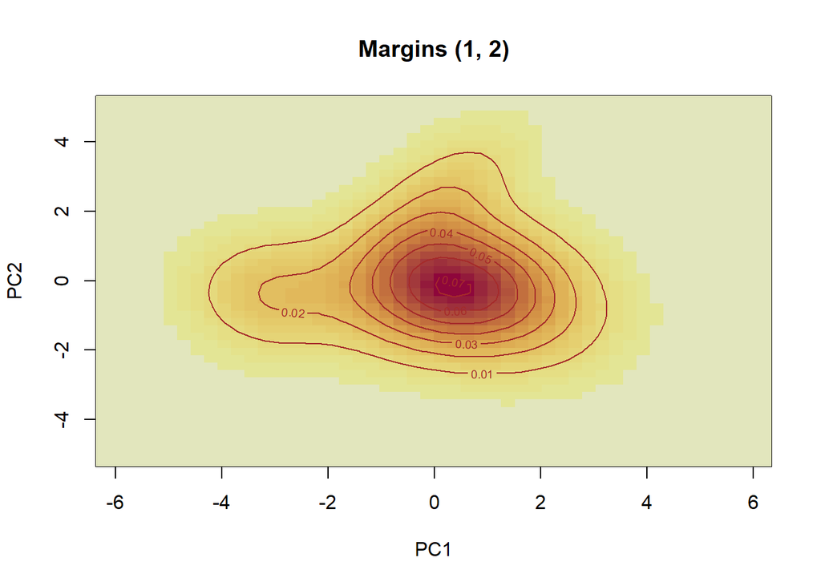

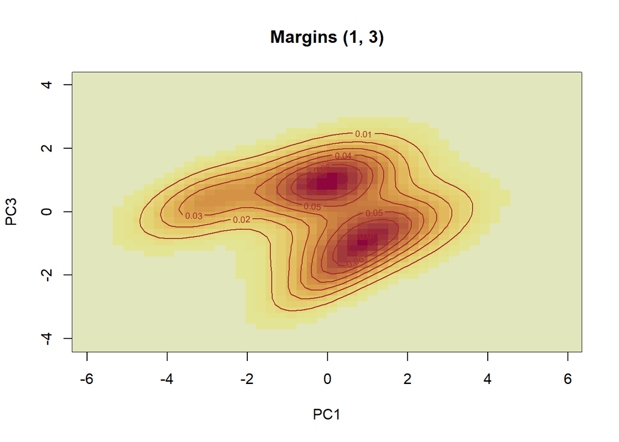

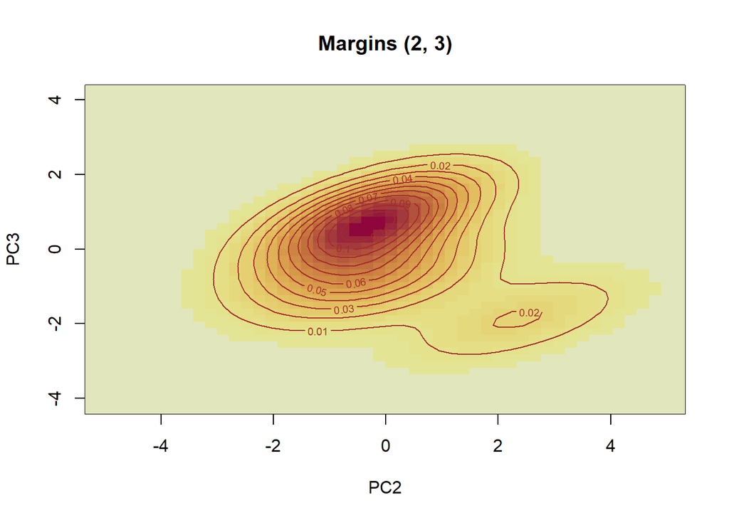

```r
# Plot bivariate mixtures
pdens2.4 <- NMixPredDensJoint2(fit.4)
plot.NMixPredDensJoint2(pdens2.4, xylab=predictors, auto.layout=FALSE)
```

```r
prob.4 <- fit.4$poster.comp.prob_u
```

Using only the 2-dimensional distributions clusters are not easly recognized, either, despite PC3 seems to discriminate 2 groups more or less clearly.

```
## [1] "Percentages of Players classified in the different clusters: "
```

```
## c.4
##    1    2    3    4
## 0.14 0.40 0.11 0.35
```

The first pattern we observe is that clusters 2 and 4 are much bigger than clusters 1 and 3.

```
## [1] "Predictions for 10 random Defenders: "
```

```
##         [,1]   [,2]  [,3]  [,4]
##  [1,] 0.9924 0.0076 0e+00 0e+00
##  [2,] 0.6821 0.3179 0e+00 0e+00
##  [3,] 0.9051 0.0949 0e+00 0e+00
##  [4,] 0.9885 0.0115 0e+00 0e+00
##  [5,] 0.9862 0.0138 0e+00 0e+00
##  [6,] 0.1332 0.8664 4e-04 0e+00
##  [7,] 0.0034 0.9957 5e-04 4e-04
##  [8,] 0.0451 0.9544 5e-04 0e+00
##  [9,] 0.1343 0.8653 4e-04 0e+00
## [10,] 0.0004 0.9991 5e-04 0e+00
```

```
## [1] "Percentages of Defenders classified in the different clusters: "
```

```
## c.4.df
##    1    2    4
## 0.37 0.62 0.01
```

Defenders are distributed more or less evenly in groups 1 and 2. In addition, for some of the observations, the probability of belonging to cluster 1 and 2 are very similar.

```
## [1] "Predictions for 10 random Goalkeepers: "
```

```
##       [,1]  [,2]   [,3]   [,4]
##  [1,]    0 5e-04 0.9961 0.0034
##  [2,]    0 5e-04 0.9994 0.0001
##  [3,]    0 5e-04 0.9995 0.0000
##  [4,]    0 2e-04 0.4281 0.5717
##  [5,]    0 5e-04 0.9889 0.0106
##  [6,]    0 5e-04 0.9995 0.0000
##  [7,]    0 5e-04 0.9738 0.0257
##  [8,]    0 4e-04 0.9600 0.0396
##  [9,]    0 5e-04 0.9994 0.0001
## [10,]    0 5e-04 0.9761 0.0234
```

```
## [1] "Percentages of Goalkeepers classified in the different clusters: "
```

```
## c.4.gk
##    3    4
## 0.94 0.06
```

In the case of Goalkeepers, our clustering model have strongly grouped them one single cluster. And, when observing some of the probabilities, it seems like the confidence of this grouping is high.

```
## [1] "Predictions for 10 random Midfielders: "
```

```
##         [,1]   [,2]  [,3]   [,4]
##  [1,] 0.0000 0.1781 3e-04 0.8216
##  [2,] 0.0552 0.8764 3e-04 0.0681
##  [3,] 0.0000 0.3614 1e-04 0.6385
##  [4,] 0.0702 0.9293 5e-04 0.0000
##  [5,] 0.0000 0.9112 5e-04 0.0883
##  [6,] 0.0000 0.0124 0e+00 0.9876
##  [7,] 0.0000 0.9881 5e-04 0.0114
##  [8,] 0.0020 0.9975 5e-04 0.0000
##  [9,] 0.0000 0.9927 5e-04 0.0068
## [10,] 0.0000 0.0067 0e+00 0.9933
```

```
## [1] "Percentages of Midfielders classified in the different clusters: "
```

```
## c.4.mf
##    1    2    4
## 0.00 0.62 0.38
```

As it happened with the Defenders, the mixture model does not group all Midfielders in one single group. They are distributed among several clusters, and some observation probabilities are very similar for all of them.

```
## [1] "Predictions for 10 random Strikers: "
```

```
##       [,1]   [,2]   [,3]   [,4]
##  [1,]    0 0.0001 0.0176 0.9823
##  [2,]    0 0.0276 0.0001 0.9723
##  [3,]    0 0.0001 0.0012 0.9987
##  [4,]    0 0.0030 0.0008 0.9962
##  [5,]    0 0.0045 0.0001 0.9954
##  [6,]    0 0.0030 0.0028 0.9942
##  [7,]    0 0.0001 0.0000 0.9999
##  [8,]    0 0.0131 0.0010 0.9859
##  [9,]    0 0.0005 0.0099 0.9896
## [10,]    0 0.0018 0.0007 0.9975
```

```
## [1] "Percentages of Strikers classified in the different clusters: "
```

```
## c.4.st
##    2    3    4
## 0.06 0.01 0.93
```

Strikers, as it happened with Goalkeepers, are grouped in one single group.

Summarizing, there is one cluster for Goalkeepers and another for Strikers; Midfielders are in the Strikers’ group and in a third group; and Defenders are evenly distributed between this third group and another group.

With respect to the probabilities, from this small subset, we have seen how most observations are strongly classified in one of the clusters. However, there is also an important amount of observations where the probability of belonging to one cluster or another is not so deterministic. This happens mostly for Defenders and Midfielders, while Goalkeepers and Strikers are classified with higher confidence, in general.

##### K = 2.

Let’s now compute the algorithm fixing the number of distributions to 2.

```r
set.seed(0)
# Check now with 2 groups (Goalkeepers and outfield players)
Prior.2 <- list(priorK = "fixed", Kmax = 2)

fit.2 <- NMixMCMC(y0 = fifa.x.pca, prior = Prior.2, nMCMC = nMCMC,
                  scale = list(shift=0, scale=1), PED = F)
```

```
##
## Chain number 1
## ==============
## MCMC sampling started on Sat Mar 30 23:17:24 2019.
## Burn-in iteration 10002000300040005000
## Iteration 6000700080009000100001100012000130001400015000
## MCMC sampling finished on Sat Mar 30 23:19:35 2019.
```

*Check for convergence.*

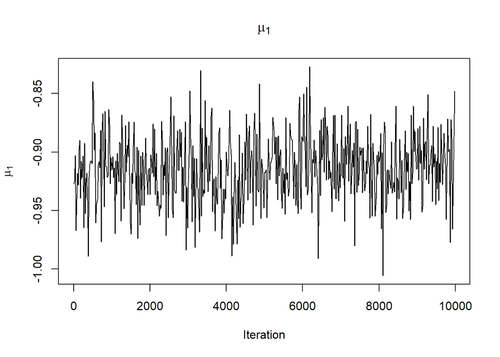

```r
# K is fixed, so check convergence of mu and omega (the covariance matrix will be difficult to plot)
plot(seq(from = 1, to = 10000, by = 20), fit.2$mu[seq(1, 10000, 20),1],
     type='n', main=expression(paste(mu[1])), xlab='Iteration',
     ylab=expression(paste(mu[1])))
lines(seq(from = 1, to = 10000, by = 20), fit.2$mu[seq(1, 10000, 20),1])
```

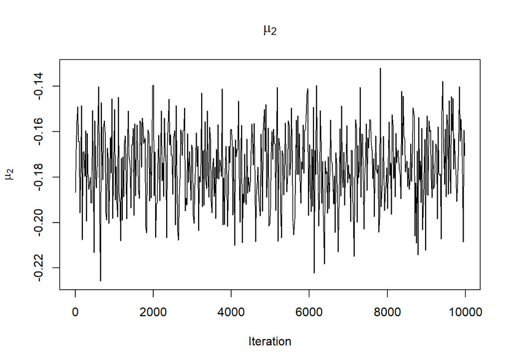

```r
plot(seq(from = 1, to = 10000, by = 20), fit.2$mu[seq(1, 10000, 20),2],
     type='n', main=expression(paste(mu[2])), xlab='Iteration',
     ylab=expression(paste(mu[2])))
lines(seq(from = 1, to = 10000, by = 20), fit.2$mu[seq(1, 10000, 20),2])
```

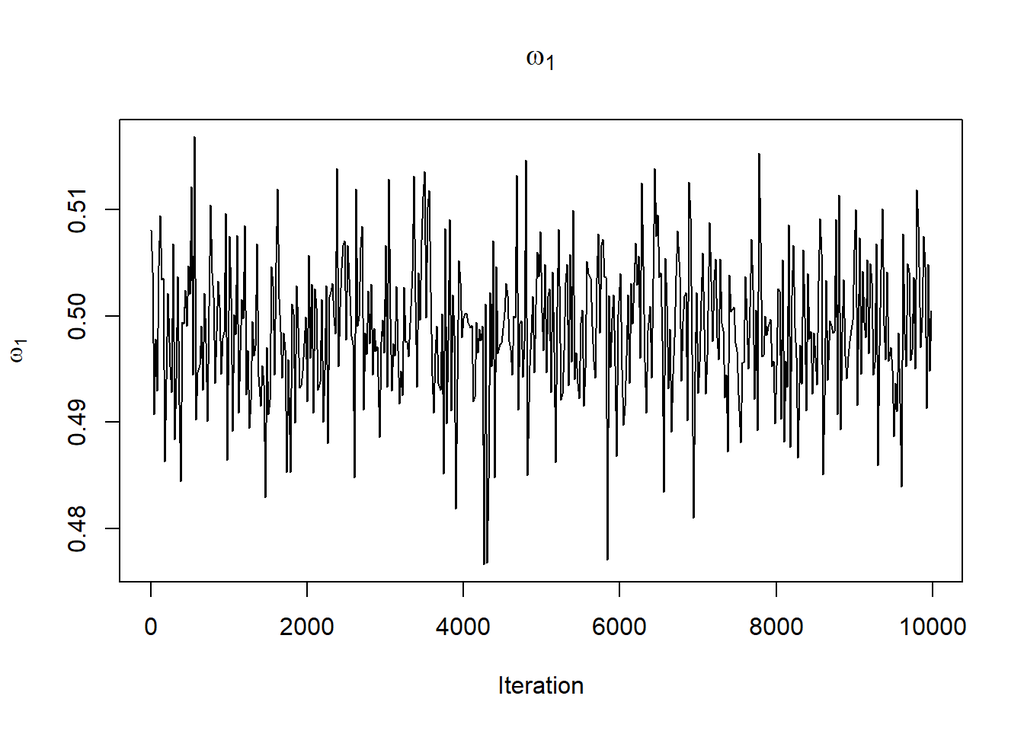

```r
plot(seq(from = 1, to = 10000, by = 20), fit.2$w[seq(1, 10000, 20),1],
     type='n', main=expression(paste(omega[1])), xlab='Iteration',
     ylab=expression(paste(omega[1])))
lines(seq(from = 1, to = 10000, by = 20), fit.2$w[seq(1, 10000, 20),1])
```

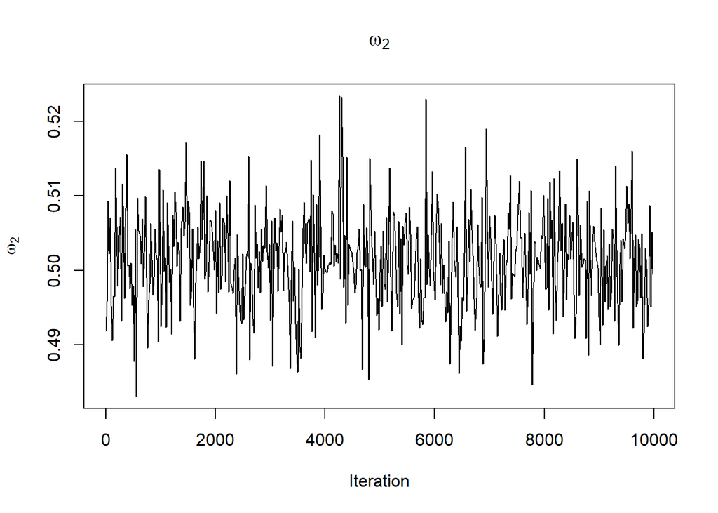

```r
plot(seq(from = 1, to = 10000, by = 20), fit.2$w[seq(1, 10000, 20),2],
     type='n', main=expression(paste(omega[2])), xlab='Iteration',
     ylab=expression(paste(omega[2])))
lines(seq(from = 1, to = 10000, by = 20), fit.2$w[seq(1, 10000, 20),2])
```

Once again, parameter values oscillate, but these oscillations do not disappear when using 20000 or 30000 iterations.

We will now plot the distributions in 1D (univariate) and in 2D (bivariate).

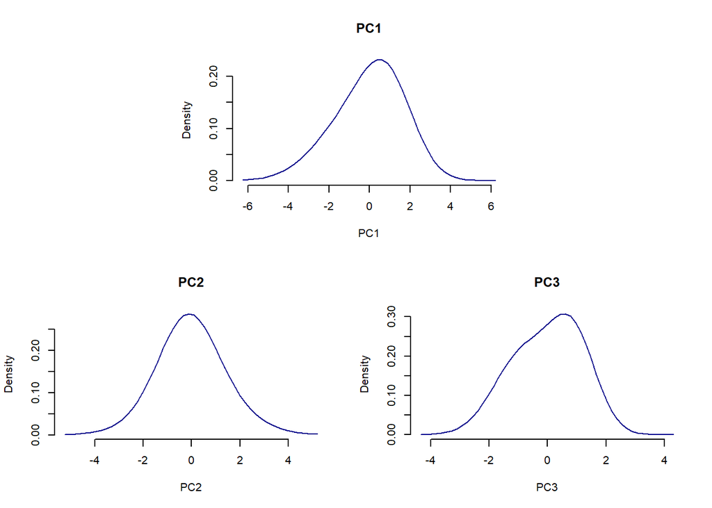

```r
# Plot univariate mixtures
pdens1.2 <- NMixPredDensMarg(fit.2, lgrid=50)
plot(pdens1.2, main=predictors, xlab=predictors)
```

As it happened when fixing the number of distributions to 4, from the graphs of the 1 dimensional distributions, the clusters are not very visual. The distributions found are quite overlapped, except perhaps for PC3.

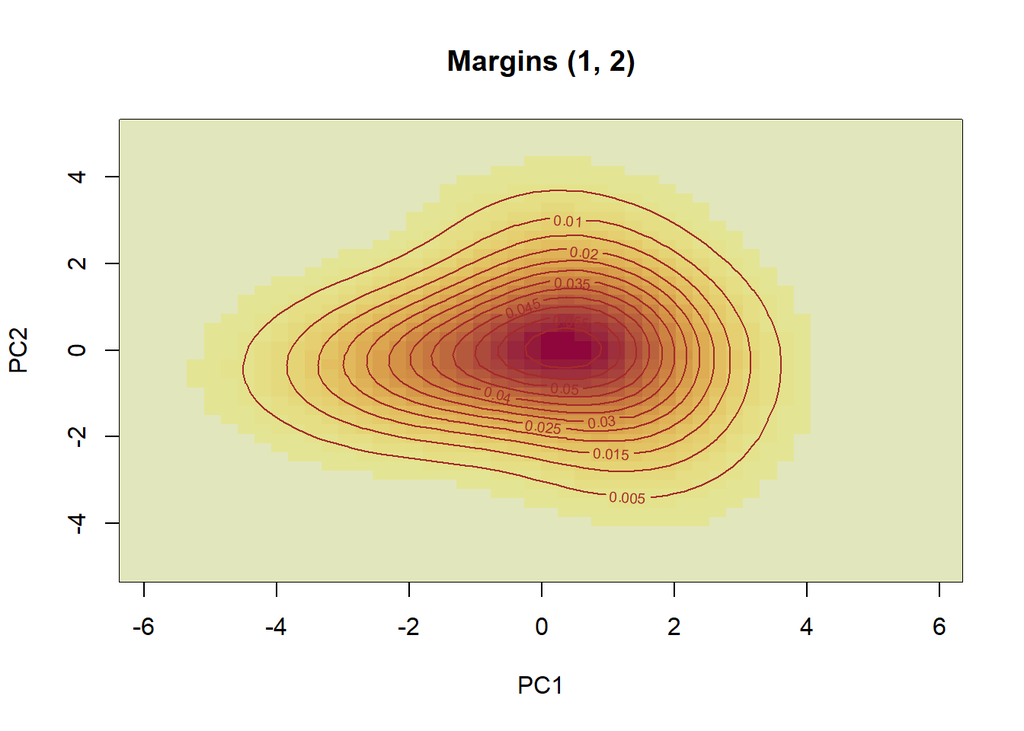

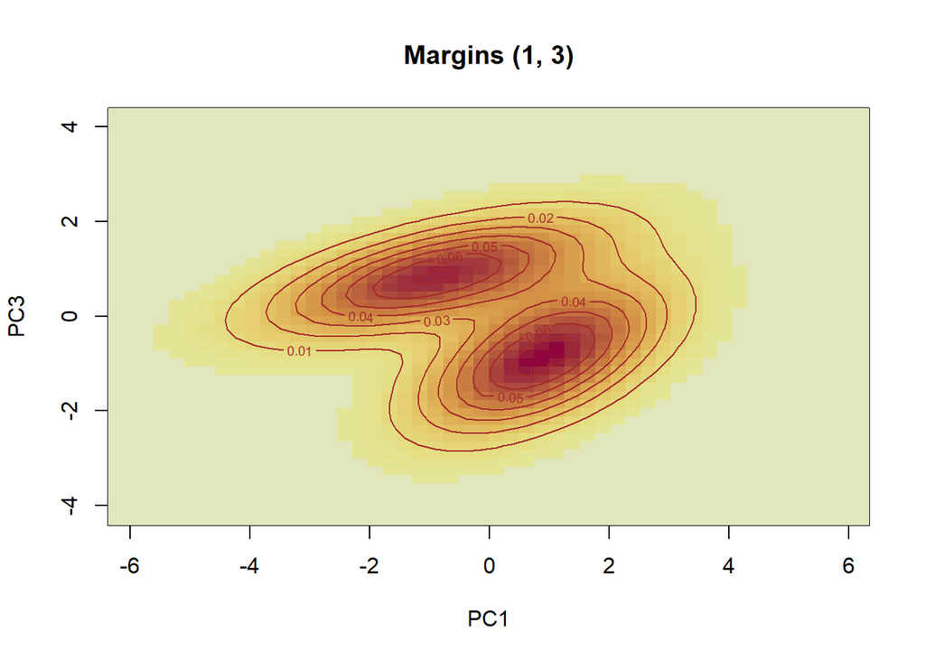

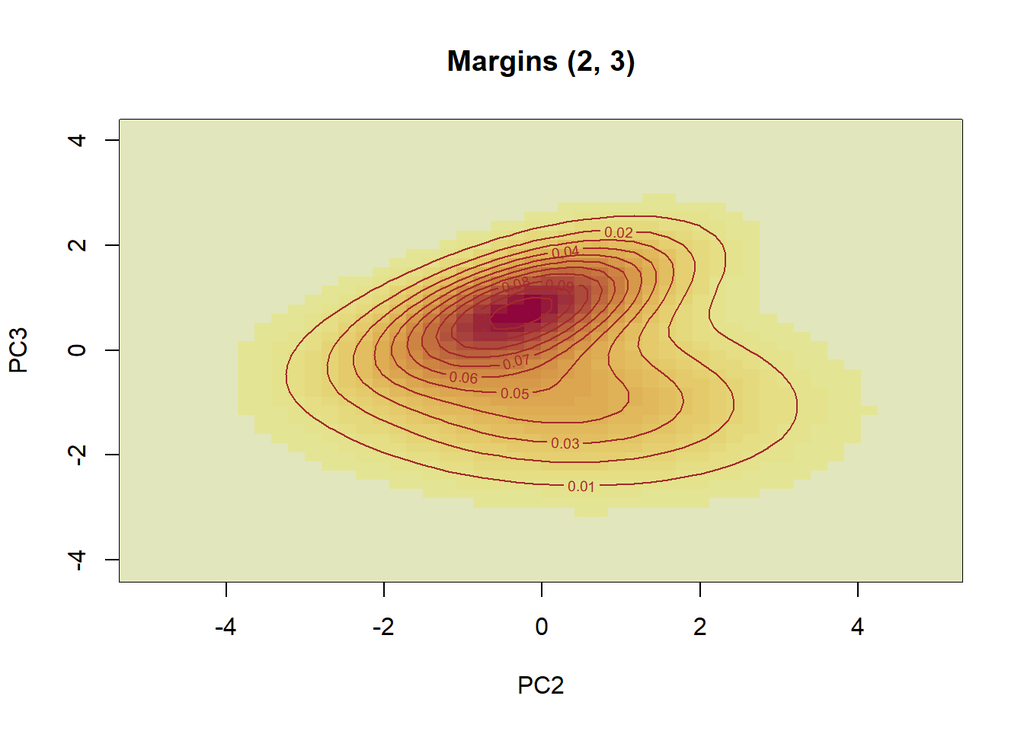

```r
# Plot bivariate mixtures
pdens2.2 <- NMixPredDensJoint2(fit.2)
plot.NMixPredDensJoint2(pdens2.2, xylab=predictors, auto.layout=FALSE)
```

```r
prob.2 <- fit.2$poster.comp.prob_u
```

In the case of the bivariate distributions, we can differenciate the clusters when PC3 comes into play. In the other figure, the two distributions overlap a lot.

```
## [1] "Percentages of Players classified in the different clusters: "
```

```
## c.2
##    1    2
## 0.51 0.49
```

When using only two clusters, both are created of similar size, with similar number of observations grouped in both of them.

```
## [1] "Predictions for 10 random Defenders: "
```

```
##         [,1]   [,2]
##  [1,] 1.0000 0.0000
##  [2,] 0.9988 0.0012
##  [3,] 1.0000 0.0000
##  [4,] 0.9998 0.0002
##  [5,] 1.0000 0.0000
##  [6,] 0.9814 0.0186
##  [7,] 0.9973 0.0027
##  [8,] 0.9995 0.0005
##  [9,] 0.9998 0.0002
## [10,] 0.9994 0.0006
```

```
## [1] "Percentages of Defenders classified in the different clusters: "
```

```
## c.2.df
##    1    2
## 0.98 0.02
```

Defenders are mostly grouped in cluster 1 and in general with high confidence in the assignment.

```
## [1] "Predictions for 10 random Goalkeepers: "
```

```
##       [,1] [,2]
##  [1,]    0    1
##  [2,]    0    1
##  [3,]    0    1
##  [4,]    0    1
##  [5,]    0    1
##  [6,]    0    1
##  [7,]    0    1
##  [8,]    0    1
##  [9,]    0    1
## [10,]    0    1
```

```
## [1] "Percentages of Goalkeepers classified in the different clusters: "
```

```
## c.2.gk
## 2
## 1
```

On the other hand, Goalkeepers are grouped undoubtfully in cluster 2.

```
## [1] "Predictions for 10 random Midfielders: "
```

```
##         [,1]   [,2]
##  [1,] 0.0239 0.9761
##  [2,] 0.8830 0.1170
##  [3,] 0.1526 0.8474
##  [4,] 0.9990 0.0010
##  [5,] 0.6587 0.3413
##  [6,] 0.0048 0.9952
##  [7,] 0.9002 0.0998
##  [8,] 0.9986 0.0014
##  [9,] 0.9698 0.0302
## [10,] 0.0087 0.9913
```

```
## [1] "Percentages of Midfielders classified in the different clusters: "
```

```
## c.2.mf
##    1    2
## 0.53 0.47
```

Midfielders are in this case particular, since the mixture model is not able to group them in any of the cluster. They are located in cluster 1 or 2 and in many cases with high confidence. This makes us believe the criteria for grouping the players is not related with their position, but with other criteria such as physical attributes (height, speed, etc).

```
## [1] "Predictions for 10 random Strikers: "
```

```
##         [,1]   [,2]
##  [1,] 0.0000 1.0000
##  [2,] 0.0137 0.9863
##  [3,] 0.0000 1.0000
##  [4,] 0.0005 0.9995
##  [5,] 0.0005 0.9995
##  [6,] 0.0005 0.9995
##  [7,] 0.0001 0.9999
##  [8,] 0.0027 0.9973
##  [9,] 0.0001 0.9999
## [10,] 0.0008 0.9992
```

```
## [1] "Percentages of Strikers classified in the different clusters: "
```

```
## c.2.st
##    1    2
## 0.04 0.96
```

Finally, strikers are grouped with Goalkeepers, mostly.

Then, to summarize, there is one cluster with the Strikers and Goalkeepers (with high confidence in the assignment), another with the Defenders (again with high confidence in the assignment) and Midfielders are pretty much everywhere.

##### K = 3.

Let’s now use the Mixture Model with 3 clusters.

```r
set.seed(0)
# Check now with 3 groups (Goalkeepers, defensive players and offensive players)
Prior.3 <- list(priorK = "fixed", Kmax = 3)

fit.3 <- NMixMCMC(y0 = fifa.x.pca, prior = Prior.3, nMCMC = nMCMC,
                  scale = list(shift=0, scale=1), PED = F)
```

```
##
## Chain number 1
## ==============
## MCMC sampling started on Sat Mar 30 23:19:49 2019.
## Burn-in iteration 10002000300040005000
## Iteration 6000700080009000100001100012000130001400015000
## MCMC sampling finished on Sat Mar 30 23:23:02 2019.
```

*Check for convergence.*

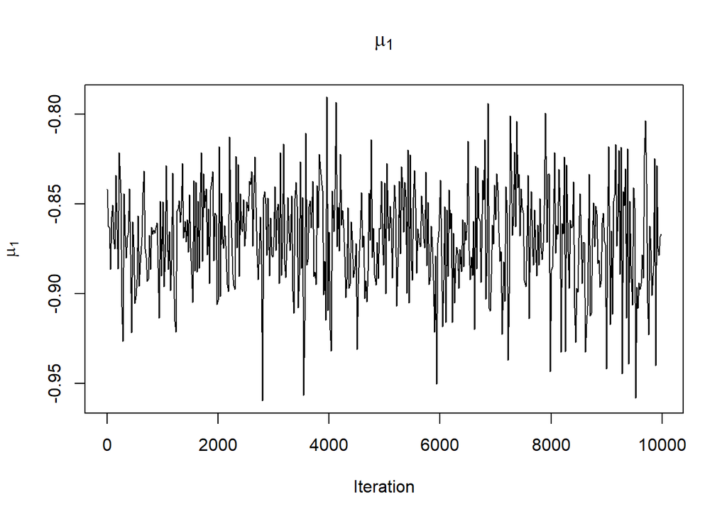

```r
# K is fixed, so check convergence of mu and omega (the covariance matrix will be difficult to plot)
plot(seq(from = 1, to = 10000, by = 20), fit.3$mu[seq(1, 10000, 20),1],
     type='n', main=expression(paste(mu[1])), xlab='Iteration',
     ylab=expression(paste(mu[1])))
lines(seq(from = 1, to = 10000, by = 20), fit.3$mu[seq(1, 10000, 20),1])
```

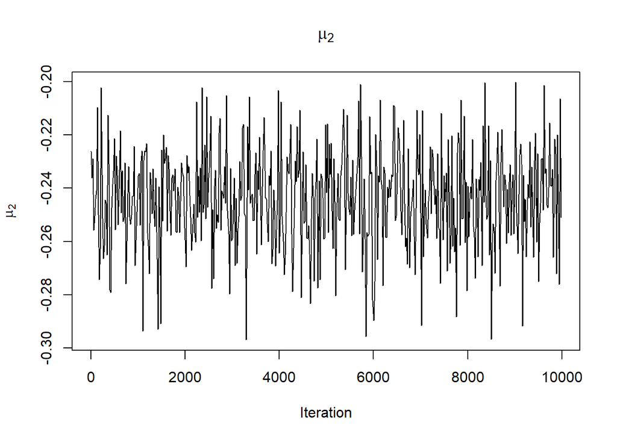

```r
plot(seq(from = 1, to = 10000, by = 20), fit.3$mu[seq(1, 10000, 20),2],
     type='n', main=expression(paste(mu[2])), xlab='Iteration',
     ylab=expression(paste(mu[2])))
lines(seq(from = 1, to = 10000, by = 20), fit.3$mu[seq(1, 10000, 20),2])
```

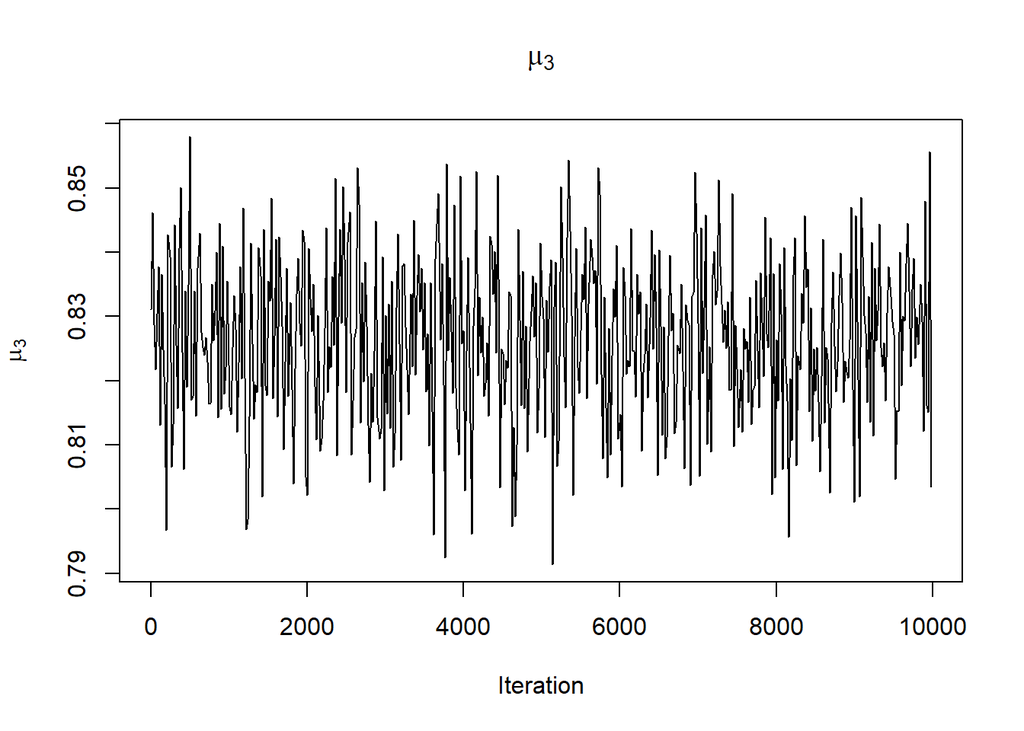

```r
plot(seq(from = 1, to = 10000, by = 20), fit.3$mu[seq(1, 10000, 20),3],
     type='n', main=expression(paste(mu[3])), xlab='Iteration',
     ylab=expression(paste(mu[3])))
lines(seq(from = 1, to = 10000, by = 20), fit.3$mu[seq(1, 10000, 20),3])
```

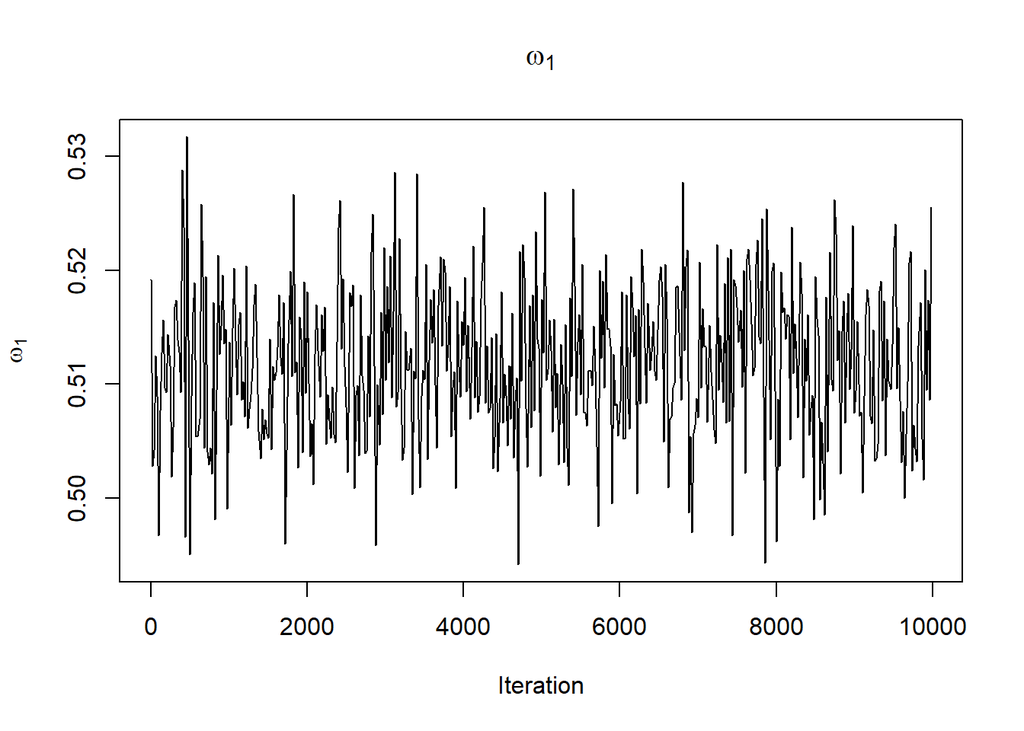

```r
plot(seq(from = 1, to = 10000, by = 20), fit.3$w[seq(1, 10000, 20),1],
     type='n', main=expression(paste(omega[1])), xlab='Iteration',
     ylab=expression(paste(omega[1])))
lines(seq(from = 1, to = 10000, by = 20), fit.3$w[seq(1, 10000, 20),1])
```

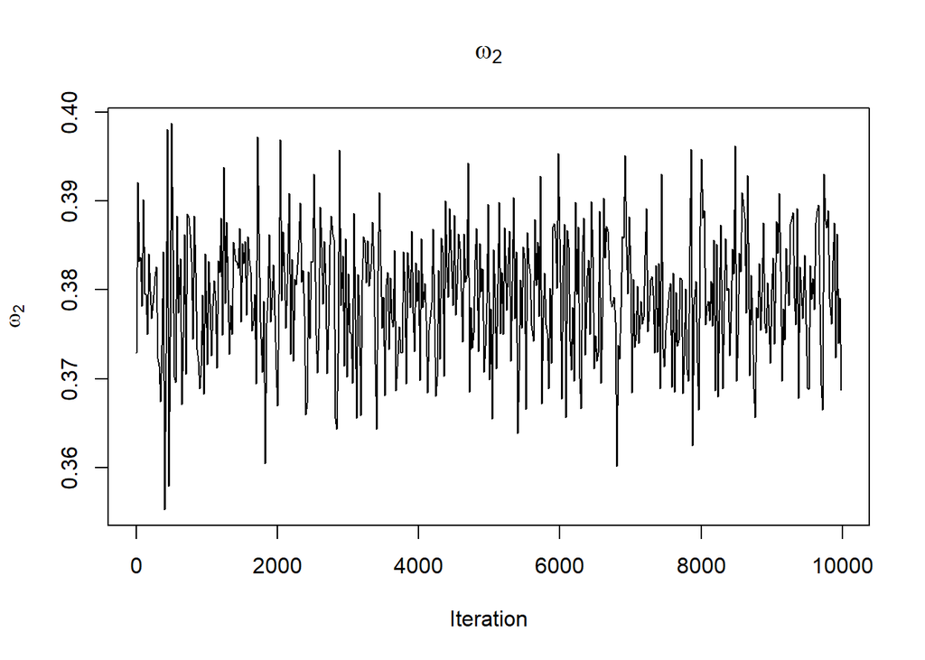

```r
plot(seq(from = 1, to = 10000, by = 20), fit.3$w[seq(1, 10000, 20),2],
     type='n', main=expression(paste(omega[2])), xlab='Iteration',
     ylab=expression(paste(omega[2])))
lines(seq(from = 1, to = 10000, by = 20), fit.3$w[seq(1, 10000, 20),2])
```

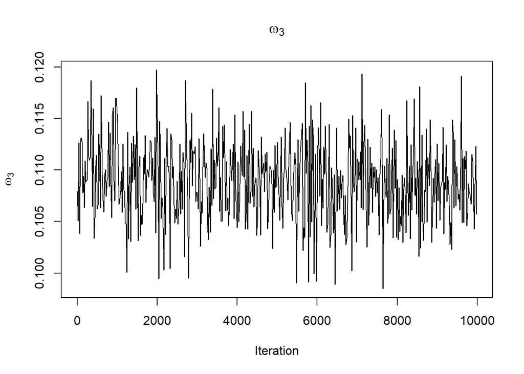

```r
plot(seq(from = 1, to = 10000, by = 20), fit.3$w[seq(1, 10000, 20),3],
     type='n', main=expression(paste(omega[3])), xlab='Iteration',
     ylab=expression(paste(omega[3])))
lines(seq(from = 1, to = 10000, by = 20), fit.3$w[seq(1, 10000, 20),3])
```

Once again, parameter values oscillate, but these oscillations do not disappear when using 20000 or 30000 iterations.

We will now plot the distributions in 1D (univariate) and in 2D (bivariate).

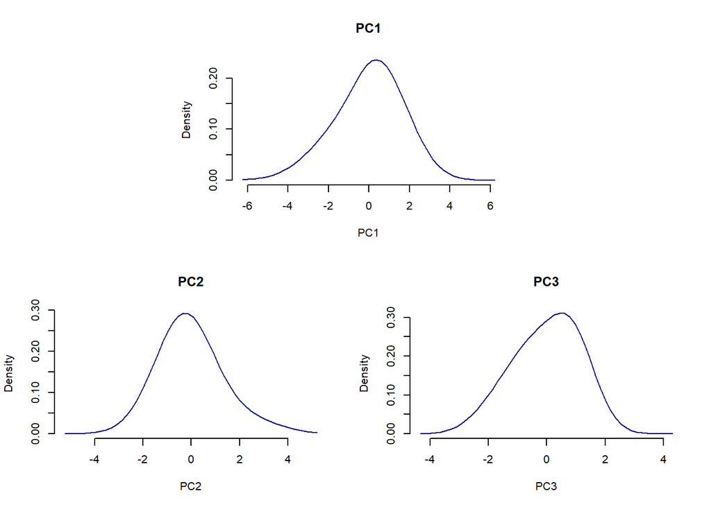

```r
# Plot univariate mixtures
pdens1.3 <- NMixPredDensMarg(fit.3, lgrid=50)
plot(pdens1.3, main=predictors, xlab=predictors)
```

Finally, when fixing the number of distributions to 3, in the three attributes the three gaussians seem to be one in top of the others, they cannot be distinguished by the naked eye.

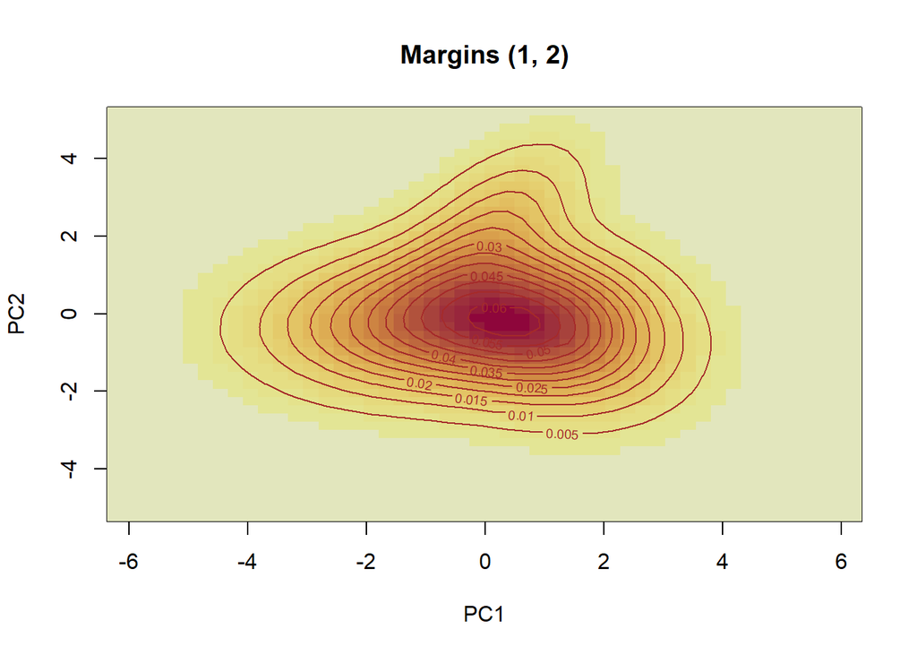

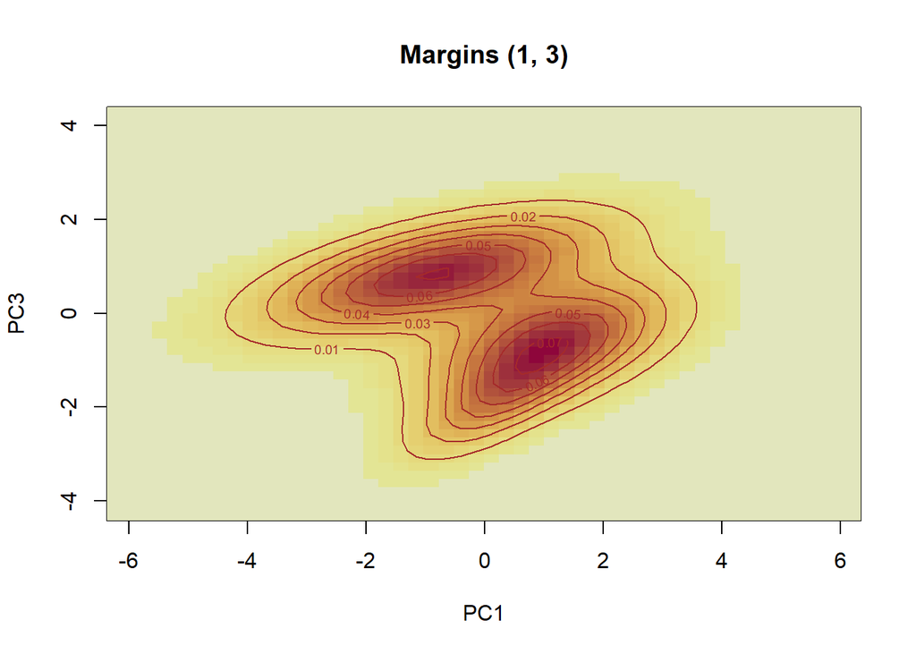

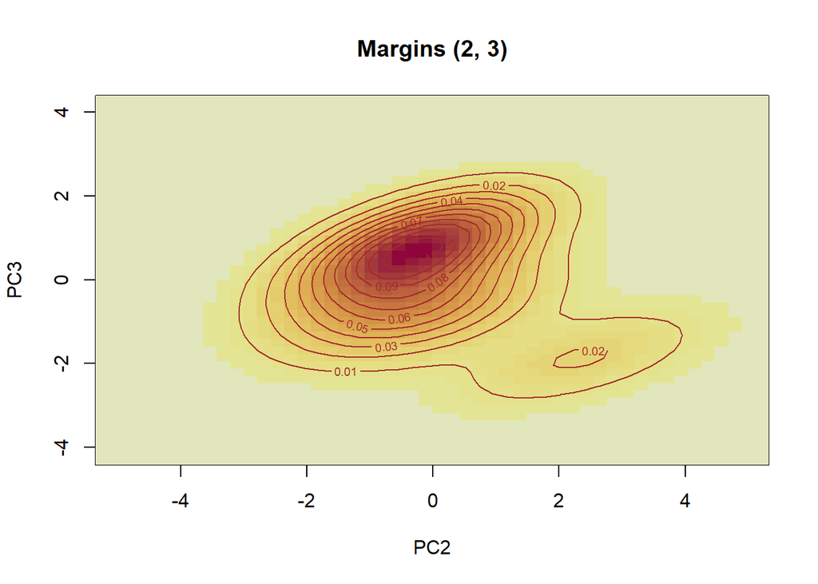

```r
# Plot bivariate mixtures
pdens2.3 <- NMixPredDensJoint2(fit.3)
plot.NMixPredDensJoint2(pdens2.3, xylab=predictors, auto.layout=FALSE)
```

```r
prob.3 <- fit.3$poster.comp.prob_u
```

Once again, as it happened with 2 distributions, the plots of the bivariate distributions only show a clue of distinct clusters when PC3 comes into play.

```
## [1] "Percentages of Players classified in the different clusters: "
```

```
## c.3
##    1    2    3
## 0.51 0.11 0.38
```

It is observed how the three clusters have different sizes.

```
## [1] "Predictions for 10 random Defenders: "
```

```
##         [,1] [,2]   [,3]
##  [1,] 1.0000    0 0.0000
##  [2,] 1.0000    0 0.0000
##  [3,] 0.9998    0 0.0002
##  [4,] 1.0000    0 0.0000
##  [5,] 1.0000    0 0.0000
##  [6,] 0.9999    0 0.0001
##  [7,] 0.9981    0 0.0019
##  [8,] 1.0000    0 0.0000
##  [9,] 1.0000    0 0.0000
## [10,] 1.0000    0 0.0000
```

```
## [1] "Percentages of Defenders classified in the different clusters: "
```

```
## c.3.df
##    1    3
## 0.99 0.01
```

Defenders are, in this case, classified with high confidence in only one of the clusters. The percentage of defenders in other groups is very small.

```
## [1] "Predictions for 10 random Goalkeepers: "
```

```
##       [,1]   [,2]   [,3]
##  [1,]    0 0.9948 0.0052
##  [2,]    0 0.9998 0.0002
##  [3,]    0 1.0000 0.0000
##  [4,]    0 0.4780 0.5220
##  [5,]    0 0.9860 0.0140
##  [6,]    0 0.9999 0.0001
##  [7,]    0 0.9696 0.0304
##  [8,]    0 0.9538 0.0462
##  [9,]    0 0.9999 0.0001
## [10,]    0 0.9781 0.0219
```

```
## [1] "Percentages of Goalkeepers classified in the different clusters: "
```

```
## c.3.gk
##    2    3
## 0.94 0.06
```

Goalkeepers are also classified in general with high confidence in one of the clusters (in a different one than that of the Defenders).

```
## [1] "Predictions for 10 random Midfielders: "
```

```
##         [,1]  [,2]   [,3]
##  [1,] 0.0381 0e+00 0.9619
##  [2,] 0.8761 0e+00 0.1239
##  [3,] 0.1143 0e+00 0.8857
##  [4,] 0.9996 0e+00 0.0004
##  [5,] 0.7546 0e+00 0.2454
##  [6,] 0.0025 1e-04 0.9974
##  [7,] 0.9547 0e+00 0.0453
##  [8,] 0.9999 0e+00 0.0001
##  [9,] 0.9639 0e+00 0.0361
## [10,] 0.0042 0e+00 0.9958
```

```
## [1] "Percentages of Midfielders classified in the different clusters: "
```

```
## c.3.mf
##    1    3
## 0.55 0.45
```

As it has happened in all the other clusterings, Midfielders are not grouped in one single cluster. In this case, they are placed in the Defenders’ cluster or in the Striker’s cluster. They have different characteristics (just compare AndrÃ©s Iniesta with Arturo Vidal, for example) and therefore it is difficult to find common patterns that they all share.

```
## [1] "Predictions for 10 random Strikers: "
```

```
##         [,1]   [,2]   [,3]
##  [1,] 0.0000 0.0215 0.9785
##  [2,] 0.0045 0.0000 0.9955
##  [3,] 0.0001 0.0013 0.9986
##  [4,] 0.0005 0.0013 0.9982
##  [5,] 0.0005 0.0004 0.9991
##  [6,] 0.0003 0.0028 0.9969
##  [7,] 0.0001 0.0001 0.9998
##  [8,] 0.0016 0.0008 0.9976
##  [9,] 0.0001 0.0100 0.9899
## [10,] 0.0002 0.0010 0.9988
```

```
## [1] "Percentages of Strikers classified in the different clusters: "
```

```
## c.3.st
##    1    2    3
## 0.04 0.01 0.95
```

Finally, Strikers are grouped most of them with high confidence in a third cluster that they share with some of the Midfielders.

As a general remark for all the clustering scenarios, we observe how the univariate mixtures are quite unimodal. In addition, many of the bivariate mixtures are also unimodal (despite some of them are bimodal) and very similar no matter the fixed number of clusters! Using the attributes transformed with PCA we are not getting distributions that show a greater number of modes. However, some interesting insights have been observed.

First, Midfielders have very different characteristics and cannot be placed in one single group by an unsupervised algorithm. They share attribute values with both Strikers and Defenders. This will make their classification more complicated.

Second, in some sense, Goalkeepers and Strikers share some abilities, since they are grouped together when $K = 2$.

Finally, Defenders are different from Goalkeepers and Strikers, but not so different, since in some scenarios they were grouped with the later.

# 5. Bayesian Classification.

### 5.1 Gaussian Processes.

We will now use Gaussian Processes for classification of the position of the players. In our case, we will use a Gaussian kernel, among the many possibilities offered by the library. The values this kernel takes for each of the points results in the covariance matrix used in the distribution of functions:

$$\begin{pmatrix}
f \\
f_{*}
\end{pmatrix} \sim N (
\begin{pmatrix}
\mu \\
\mu_{*}
\end{pmatrix},
\begin{pmatrix}
K & K_{*} \\
K_{*}^T & K_{**}
\end{pmatrix})$$

where the asterisk ($*$) denotes the unobserved points and $\sum$ is the kernel in the covariance matrix that computes the distance between points. An standard RBF kernel will be used because in projects of other subjects it has proved to be quite powerful and the computational cost of testing many kernels is high (considering our resources). The hyperparameters of this kernel are automatically optimized by the library.

Gaussian Processes were developed for regression. The idea behind is to fit a distribution of functions, instead of a single function as we used to do in classical regression. To be extended to classification we use the same trick as in logistic regression: we predict the log probability of belonging to a class (in our case, of being a Defender, Goalkeeper, Midfielder or Striker).

As in all Bayesian procedures, Gaussian Processes start with a prior distribution and update its values with the observed data. In this case, parameters are estimated using Laplace approximation, which is faster than MCMC despite it does not converge to the true value (as MCMC does). This choice was made because we did not have enough computational power to run the Gaussian Processes libraries that use MCMC.

```r
set.seed(0)
# Train the model
train_model <- gausspr(V4~.,data=fifa.train)
```

```
## Using automatic sigma estimation (sigest) for RBF or laplace kernel
```

```r
train_model
```

```
## Gaussian Processes object of class "gausspr"
## Problem type: classification
##
## Gaussian Radial Basis kernel function.
##  Hyperparameter : sigma =  0.55301529624687
##
## Number of training instances learned : 6747
## Train error : 0.191640729
```

```r
#alpha(train_model) #model parameters
error(train_model)
```

```
## [1] 0.1916407
```

```
## [1] "Predictions for 10 random Defenders: "
```

```
##        Defender  Goalkeeper  Midfielder     Striker
##  [1,] 0.9560099 0.002165605 0.036614606 0.005209840
##  [2,] 0.8195624 0.013410104 0.115894940 0.051132537
##  [3,] 0.9381393 0.012207452 0.012434994 0.037218301
##  [4,] 0.9435622 0.014490899 0.011151336 0.030795540
##  [5,] 0.9735871 0.001800077 0.019029124 0.005583731
##  [6,] 0.8903442 0.015319440 0.064492300 0.029844075
##  [7,] 0.9352527 0.007227839 0.017352014 0.040167410
##  [8,] 0.9631238 0.001879937 0.030797690 0.004198580
##  [9,] 0.4852296 0.057969596 0.262797674 0.194003155
## [10,] 0.9850247 0.001342359 0.009119089 0.004513896
```

Despite most Defenders are classified correctly (see the Confusion Matrix below), for some of them the probabilities are not high. This coincides with the unsupervised analysis, in which it was sometimes difficult to find clusters where all Defenders belonged together.

```
## [1] "Predictions for 10 random Goalkeepers: "
```

```
##          Defender Goalkeeper  Midfielder     Striker
##  [1,] 0.095150101  0.1223006 0.175622873 0.606926416
##  [2,] 0.004085977  0.9605819 0.013758935 0.021573174
##  [3,] 0.003844142  0.9864401 0.006733650 0.002982077
##  [4,] 0.003176884  0.9837328 0.006699166 0.006391112
##  [5,] 0.002467533  0.9892036 0.004851414 0.003477445
##  [6,] 0.004608655  0.9796226 0.008716616 0.007052094
##  [7,] 0.014890130  0.8317854 0.064576604 0.088747883
##  [8,] 0.002507292  0.9887612 0.005127635 0.003603894
##  [9,] 0.037914617  0.6721485 0.102734573 0.187202327
## [10,] 0.010897348  0.9529184 0.021252787 0.014931443
```

Goalkeerpers are usually classified with higher probability. However, they are sometimes confused with the strikers, since their physical attributes (height, weight, etc) and kicking abilities are similar and the Principal Components used emphasize these characteristics.

```
## [1] "Predictions for 10 random Midfielders: "
```

```
##          Defender  Goalkeeper Midfielder   Striker
##  [1,] 0.110362776 0.082426843  0.6082053 0.1990051
##  [2,] 0.016353233 0.020434135  0.7031720 0.2600406
##  [3,] 0.590511329 0.041702197  0.2233881 0.1443983
##  [4,] 0.010575761 0.003954064  0.1425105 0.8429596
##  [5,] 0.006548891 0.006652196  0.6095125 0.3772864
##  [6,] 0.010958372 0.017234844  0.7261683 0.2456384
##  [7,] 0.349006485 0.113460810  0.2633323 0.2742004
##  [8,] 0.113552634 0.084440324  0.6071660 0.1948410
##  [9,] 0.200789916 0.089199695  0.4647771 0.2452333
## [10,] 0.146216689 0.051550890  0.4025471 0.3996853
```

As anticipated by the unsupervised classification analysis, probabilities for the Midfielders are the lowest ones. Recall that the Finite Mixture of Gaussians algorithm was not able to group the Midfielders in a single cluster, since their abilities are quite heterogeneous.

```
## [1] "Predictions for 10 random Strikers: "
```

```
##          Defender  Goalkeeper Midfielder   Striker
##  [1,] 0.011903504 0.004608643 0.18180139 0.8016865
##  [2,] 0.119596807 0.169300231 0.23119768 0.4799053
##  [3,] 0.010560865 0.006720884 0.42056677 0.5621515
##  [4,] 0.014932449 0.006960759 0.19618189 0.7819249
##  [5,] 0.014502844 0.006131679 0.34519563 0.6341699
##  [6,] 0.026939096 0.009739943 0.24964706 0.7136739
##  [7,] 0.004151683 0.001894866 0.39918441 0.5947690
##  [8,] 0.031812903 0.010405428 0.10462146 0.8531602
##  [9,] 0.016322645 0.004953410 0.09026245 0.8884615
## [10,] 0.005353088 0.002540163 0.34802424 0.6440825
```

Finally, strikers are classified perhaps with more probability than Midfielders, but not as much as Goalkeepers.

```r
print('Confusion Matrix')
```

```
## [1] "Confusion Matrix"
```

```r
confusionMatrix(fifa.test.y, predclass)
```

```
## Confusion Matrix and Statistics
##
##             Reference
## Prediction   Defender Goalkeeper Midfielder Striker
##   Defender        729          0         92       3
##   Goalkeeper        0        236          0      17
##   Midfielder      122          0        334     118
##   Striker           1          7         90     501
##
## Overall Statistics
##
##                Accuracy : 0.8
##                  95% CI : (0.7829, 0.8164)
##     No Information Rate : 0.3787
##     P-Value [Acc > NIR] : < 2.2e-16
##
##                   Kappa : 0.7203
##
##  Mcnemar's Test P-Value : NA
##
## Statistics by Class:
##
##                      Class: Defender Class: Goalkeeper Class: Midfielder
## Sensitivity                   0.8556            0.9712            0.6473
## Specificity                   0.9320            0.9915            0.8616
## Pos Pred Value                0.8847            0.9328            0.5819
## Neg Pred Value                0.9137            0.9965            0.8914
## Prevalence                    0.3787            0.1080            0.2293
## Detection Rate                0.3240            0.1049            0.1484
## Detection Prevalence          0.3662            0.1124            0.2551
## Balanced Accuracy             0.8938            0.9814            0.7544
##                      Class: Striker
## Sensitivity                  0.7840
## Specificity                  0.9392
## Pos Pred Value               0.8364
## Neg Pred Value               0.9164
## Prevalence                   0.2840
## Detection Rate               0.2227
## Detection Prevalence         0.2662
## Balanced Accuracy            0.8616
```

From the confusion matrix, the first value we should focus on is the p-value of the accuracy. It determines that the accuracy is better than the “no information rate”. That is, our classifier is better than the dummy classifier that simply assigns each new instance to the majority class.

Then, the global accuracy is examined and results in a value near 80%. In addition, the $Kappa$ statistic is computed (similar to the accuracy but takes into account the possibility of agreement ocurring by chance). This value is slightly smaller than the general accuracy.

If we go class by class, it is observed from the table that, as anticipated by the Unsupervised Analysis, Goalkeepers are easy to identify, the Strikers and Defenders and finally Midfielders, which share features with other players and therefore it is complicated to classify them.

Defenders and Strikers are confused with Midfielders. Midfielders, despite being majoritarily correctly classified, are sometimes confused with Defenders or Strikers (at a similar rate). Interestingly (and as anticipated by the Unsupervised Analysis), some Goalkeepers are identified as Strikers, probably because the Principal Components we are using value more Height and Kicking abilities than other characteristics.

Specificities are, of course greater than Sensitivities since we have more than 2 classes, and also always quite high (above 90% in most classes): when the classifier says that an observation DOES NOT belong to a given class, it is usually right. In addition, Sensitivities also then to be high: when the classifier says that an observation DOES belong to a class, it is again usually right.

### 5.2 Logistic Regression.

Logistic regression is another technique borrowed by machine learning from the field of statistics. It is the go-to method for binary classification problems (problems with two class values). In the logistic model, the log-odds (the logarithm of the odds) for the value labeled “1” is a linear combination of one or more independent variables. The problem is that in this case, our variable is a categorical with four different possible values. So the way to proceed is to build a model in which one of the categories is labeled as 1, and all the others as 0. It is also known as 1 vs. all or multinomal classification.

The probability for being a goalkeeper, defender, midfielder or striker is given by the following formula, with the $\beta$ parameters for the corresponding model.

$$p_{(i)} = \frac{1}{1+e^{-{\beta_{0} + \beta_{1}*x_{1} + \beta_{2}*x_{2} + \beta_{3}*x_{3}}}}$$

Then for all the $x$ in the dataset we follow this approach in order to classify every player in the category $i$ with probability $\hat{y}$:

$$\hat{y} = argmax{(p_{i})}$$

#### 5.2.1 Frequentist approach

Model for the goalkeeper category:

```
##
## Call:
## glm(formula = bin ~ PC1 + PC2 + PC3, family = binomial(link = "logit"),
##     data = fifa.train.goalkeeper)
##
## Deviance Residuals:
##     Min       1Q   Median       3Q      Max
## -2.7439  -0.0032   0.0000   0.0000   3.8439
##
## Coefficients:
##             Estimate Std. Error z value Pr(>|z|)
## (Intercept) -15.4599     1.0794 -14.323   <2e-16 ***
## PC1           2.1381     0.2150   9.944   <2e-16 ***
## PC2           3.6313     0.2483  14.623   <2e-16 ***
## PC3          -7.6027     0.5606 -13.563   <2e-16 ***
## ---
## Signif. codes:  0 '***' 0.001 '**' 0.01 '*' 0.05 '.' 0.1 ' ' 1
##
## (Dispersion parameter for binomial family taken to be 1)
##
##     Null deviance: 4737.6  on 6746  degrees of freedom
## Residual deviance:  326.7  on 6743  degrees of freedom
## AIC: 334.7
##
## Number of Fisher Scoring iterations: 11
```

Model for the defender category:

```
##
## Call:
## glm(formula = bin ~ PC1 + PC2 + PC3, family = binomial(link = "logit"),
##     data = fifa.train.defender)
##
## Deviance Residuals:
##     Min       1Q   Median       3Q      Max
## -3.0173  -0.1529  -0.0264   0.2340   3.8028
##
## Coefficients:
##             Estimate Std. Error z value Pr(>|z|)
## (Intercept) -2.44854    0.09794  -25.00   <2e-16 ***
## PC1         -1.76233    0.05223  -33.74   <2e-16 ***
## PC2         -1.30912    0.05594  -23.40   <2e-16 ***
## PC3          2.68002    0.09014   29.73   <2e-16 ***
## ---
## Signif. codes:  0 '***' 0.001 '**' 0.01 '*' 0.05 '.' 0.1 ' ' 1
##
## (Dispersion parameter for binomial family taken to be 1)
##
##     Null deviance: 8865.6  on 6746  degrees of freedom
## Residual deviance: 2899.6  on 6743  degrees of freedom
## AIC: 2907.6
##
## Number of Fisher Scoring iterations: 7
```

Model for the midfielder category:

```
##
## Call:
## glm(formula = bin ~ PC1 + PC2 + PC3, family = binomial(link = "logit"),
##     data = fifa.train.midfielder)
##
## Deviance Residuals:
##     Min       1Q   Median       3Q      Max
## -1.8353  -0.7964  -0.4900   0.8982   2.5261
##
## Coefficients:
##             Estimate Std. Error z value Pr(>|z|)
## (Intercept) -1.31306    0.03415  -38.45   <2e-16 ***
## PC1          0.40853    0.01956   20.88   <2e-16 ***
## PC2         -0.26566    0.02327  -11.41   <2e-16 ***
## PC3          0.51494    0.02846   18.09   <2e-16 ***
## ---
## Signif. codes:  0 '***' 0.001 '**' 0.01 '*' 0.05 '.' 0.1 ' ' 1
##
## (Dispersion parameter for binomial family taken to be 1)
##
##     Null deviance: 7662.5  on 6746  degrees of freedom
## Residual deviance: 6667.1  on 6743  degrees of freedom
## AIC: 6675.1
##
## Number of Fisher Scoring iterations: 5
```

Model for the striker category:

```
##
## Call:
## glm(formula = bin ~ PC1 + PC2 + PC3, family = binomial(link = "logit"),
##     data = fifa.train.striker)
##
## Deviance Residuals:
##     Min       1Q   Median       3Q      Max
## -2.4133  -0.7027  -0.3412   0.7152   2.7037
##
## Coefficients:
##             Estimate Std. Error z value Pr(>|z|)
## (Intercept) -1.51567    0.04104  -36.94  < 2e-16 ***
## PC1          0.70911    0.02554   27.77  < 2e-16 ***
## PC2         -0.13896    0.01974   -7.04 1.92e-12 ***
## PC3         -0.77778    0.02833  -27.45  < 2e-16 ***
## ---
## Signif. codes:  0 '***' 0.001 '**' 0.01 '*' 0.05 '.' 0.1 ' ' 1
##
## (Dispersion parameter for binomial family taken to be 1)
##
##     Null deviance: 7820.9  on 6746  degrees of freedom
## Residual deviance: 5882.8  on 6743  degrees of freedom
## AIC: 5890.8
##
## Number of Fisher Scoring iterations: 5
```

Computing the predictions on the test subset and obtaining the probabilities and posterior classification with the associated confusion matrix:

```
## Confusion Matrix and Statistics
##
##             Reference
## Prediction   Defender Goalkeeper Midfielder Striker
##   Defender        761          0         57       6
##   Goalkeeper        0        238          0      15
##   Midfielder      162          0        226     186
##   Striker           7         17         74     501
##
## Overall Statistics
##
##                Accuracy : 0.7671
##                  95% CI : (0.7491, 0.7844)
##     No Information Rate : 0.4133
##     P-Value [Acc > NIR] : < 2.2e-16
##
##                   Kappa : 0.6727
##
##  Mcnemar's Test P-Value : NA
##
## Statistics by Class:
##
##                      Class: Defender Class: Goalkeeper Class: Midfielder
## Sensitivity                   0.8183            0.9333            0.6331
## Specificity                   0.9523            0.9925            0.8162
## Pos Pred Value                0.9235            0.9407            0.3937
## Neg Pred Value                0.8815            0.9915            0.9218
## Prevalence                    0.4133            0.1133            0.1587
## Detection Rate                0.3382            0.1058            0.1004
## Detection Prevalence          0.3662            0.1124            0.2551
## Balanced Accuracy             0.8853            0.9629            0.7246
##                      Class: Striker
## Sensitivity                  0.7076
## Specificity                  0.9364
## Pos Pred Value               0.8364
## Neg Pred Value               0.8746
## Prevalence                   0.3147
## Detection Rate               0.2227
## Detection Prevalence         0.2662
## Balanced Accuracy            0.8220
```

#### 5.2.2 Bayesian approach

In bayesian logistic regression, we start with an initial belief about the distribution of $p(\beta_{0}, \beta_{1}, \beta_{2}, ..., \beta_{n})$. Then $p(\beta_{0}, \beta_{1}, \beta_{2}, ..., \beta_{n} | x,y)$ is proportional to $p(y | \beta_{0}, \beta_{1}, \beta_{2}, ..., \beta_{n},x)*p(\beta_{0}, \beta_{1}, \beta_{2}, ..., \beta_{n})$. That is, the posterior, which is our updated belief about the weights given evidence, is proportional to our prior (initial belief) times the likelihood. We cannot evaluate the closed form posterior, but can approximate it by sampling or variational methods. This gives us a distribution over the weights.

Model for the goalkeeper category:

```
##
## Iterations = 1001:11000
## Thinning interval = 1
## Number of chains = 1
## Sample size per chain = 10000
##
## 1. Empirical mean and standard deviation for each variable,
##    plus standard error of the mean:
##
##                Mean     SD Naive SE Time-series SE
## (Intercept) -15.684 1.1478 0.011478       0.044841
## PC1           2.173 0.2288 0.002288       0.008684
## PC2           3.686 0.2645 0.002645       0.010309
## PC3          -7.712 0.5930 0.005930       0.023138
##
## 2. Quantiles for each variable:
##
##                2.5%     25%     50%     75%   97.5%
## (Intercept) -18.086 -16.418 -15.623 -14.846 -13.566
## PC1           1.735   2.008   2.162   2.320   2.643
## PC2           3.208   3.502   3.671   3.857   4.237
## PC3          -8.952  -8.101  -7.694  -7.284  -6.637
```

[figure not shown]

Model for the defender category:

```
##
## Iterations = 1001:11000
## Thinning interval = 1
## Number of chains = 1
## Sample size per chain = 10000
##
## 1. Empirical mean and standard deviation for each variable,
##    plus standard error of the mean:
##
##               Mean      SD  Naive SE Time-series SE
## (Intercept) -2.447 0.09693 0.0009693       0.003581
## PC1         -1.763 0.05255 0.0005255       0.001900
## PC2         -1.309 0.05536 0.0005536       0.002057
## PC3          2.681 0.08914 0.0008914       0.003270
##
## 2. Quantiles for each variable:
##
##               2.5%    25%    50%    75%  97.5%
## (Intercept) -2.638 -2.513 -2.446 -2.380 -2.259
## PC1         -1.867 -1.799 -1.762 -1.725 -1.667
## PC2         -1.418 -1.347 -1.306 -1.272 -1.203
## PC3          2.508  2.621  2.680  2.740  2.861
```

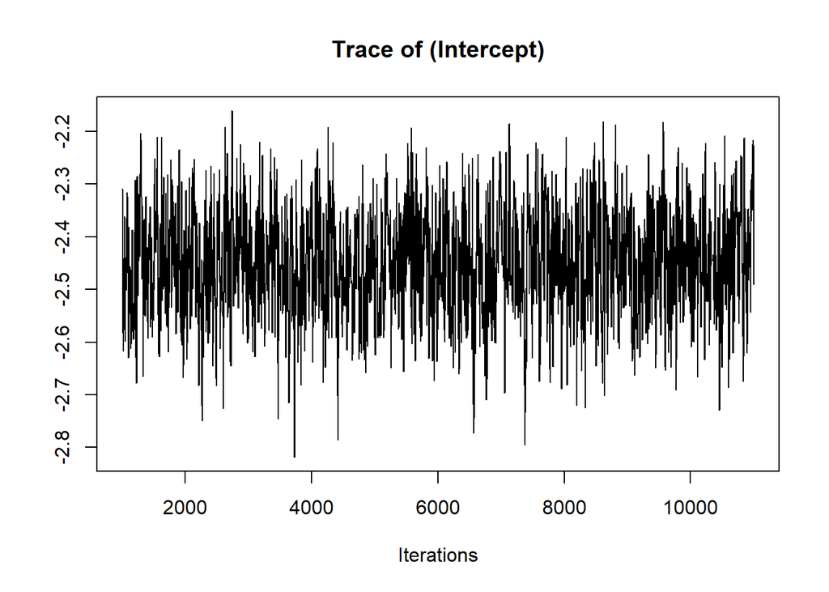

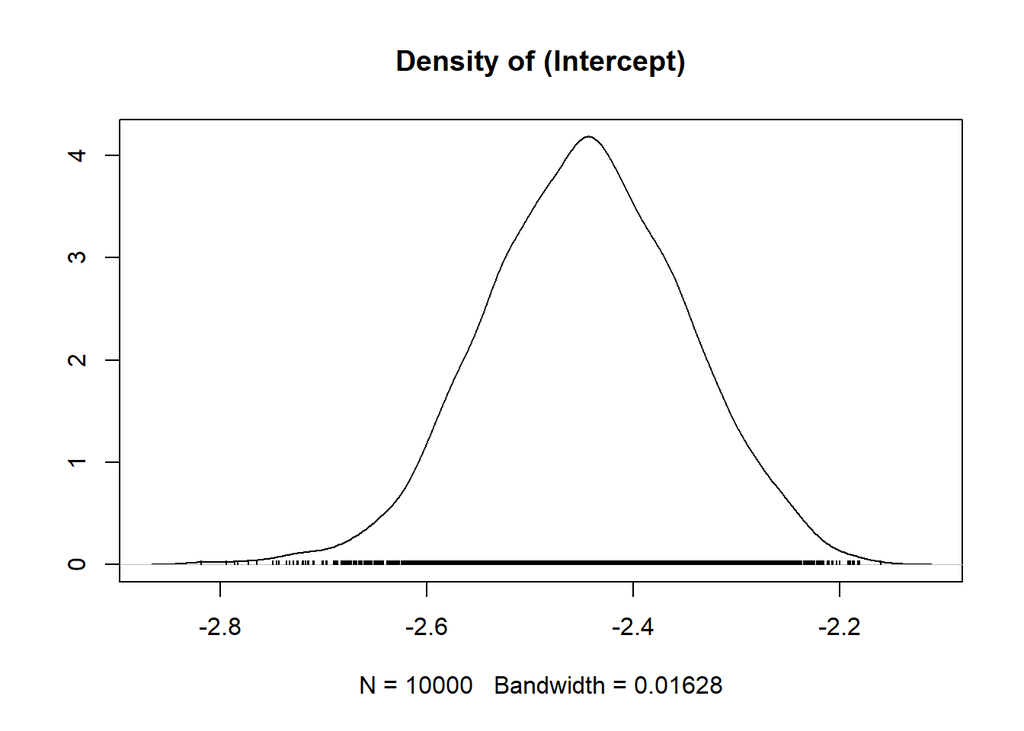

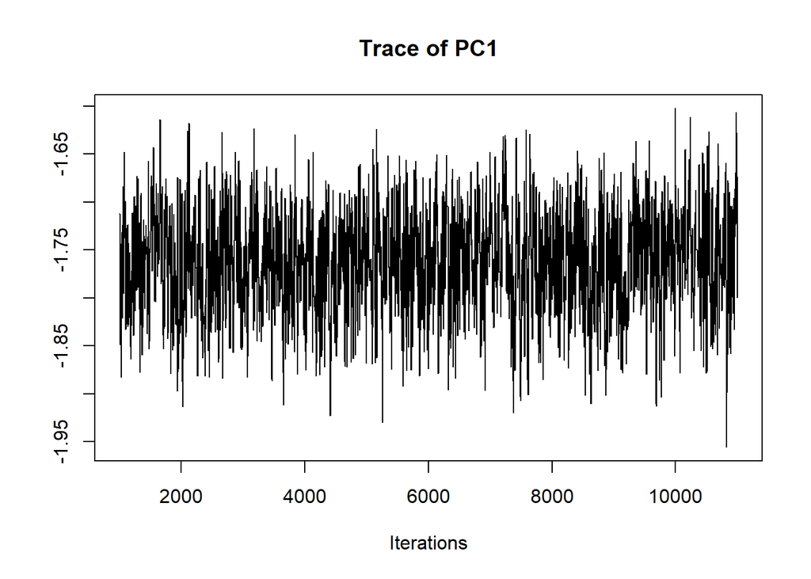

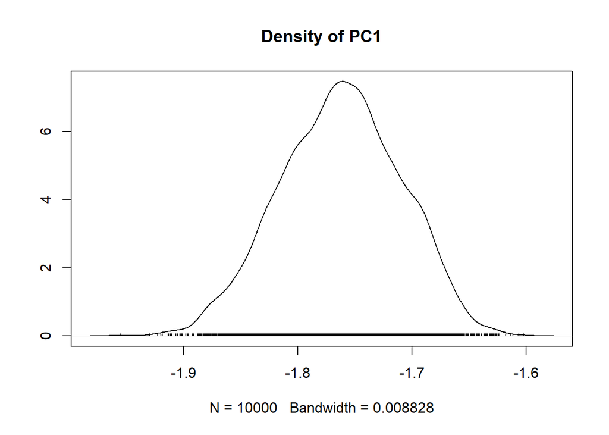

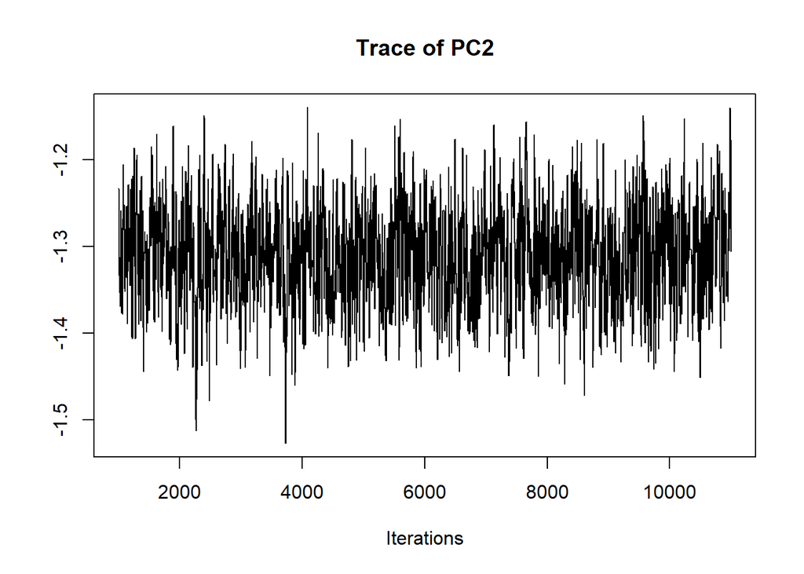

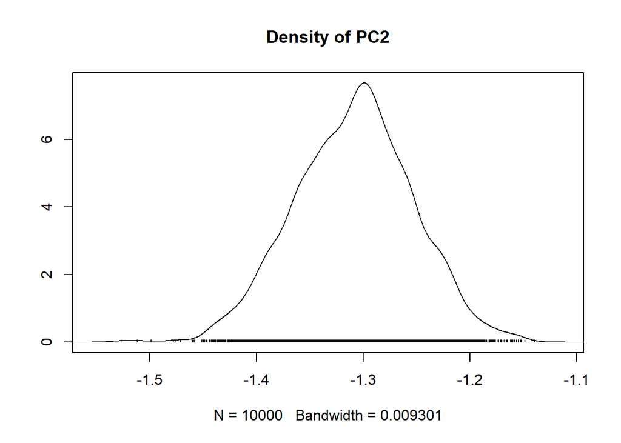

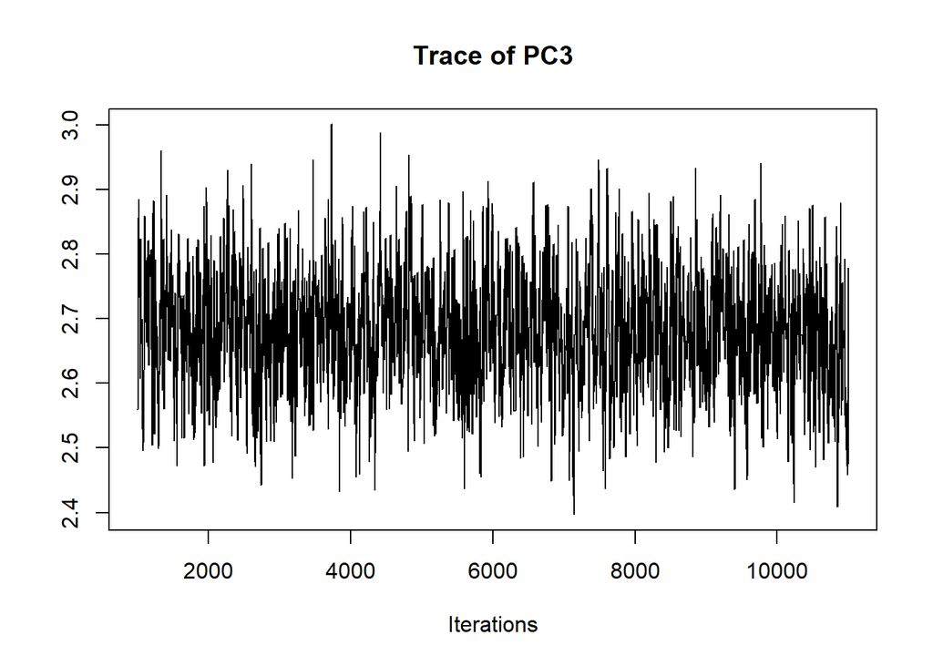

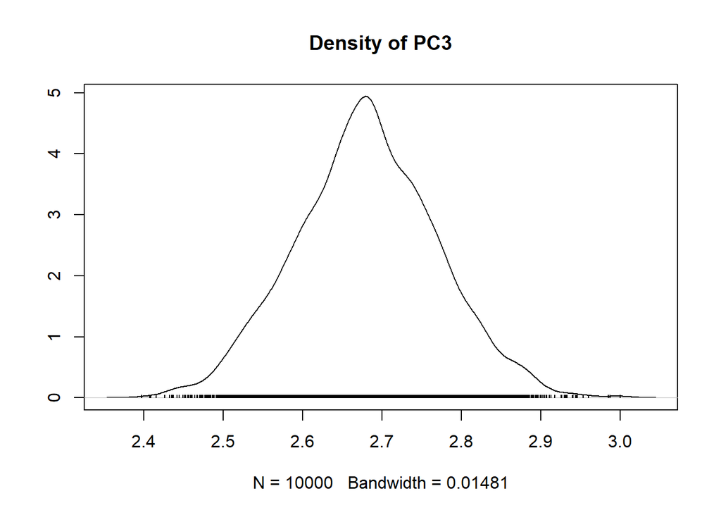

Model for the midfielder category:

```
##
## Iterations = 1001:11000
## Thinning interval = 1
## Number of chains = 1
## Sample size per chain = 10000
##
## 1. Empirical mean and standard deviation for each variable,
##    plus standard error of the mean:
##
##                Mean      SD  Naive SE Time-series SE
## (Intercept) -1.3144 0.03406 0.0003406      0.0012425
## PC1          0.4093 0.01993 0.0001993      0.0007384
## PC2         -0.2655 0.02312 0.0002312      0.0008625
## PC3          0.5161 0.02805 0.0002805      0.0010129
##
## 2. Quantiles for each variable:
##
##                2.5%     25%     50%     75%   97.5%
## (Intercept) -1.3819 -1.3370 -1.3135 -1.2914 -1.2508
## PC1          0.3720  0.3953  0.4089  0.4226  0.4487
## PC2         -0.3137 -0.2807 -0.2653 -0.2500 -0.2206
## PC3          0.4627  0.4981  0.5154  0.5352  0.5716
```

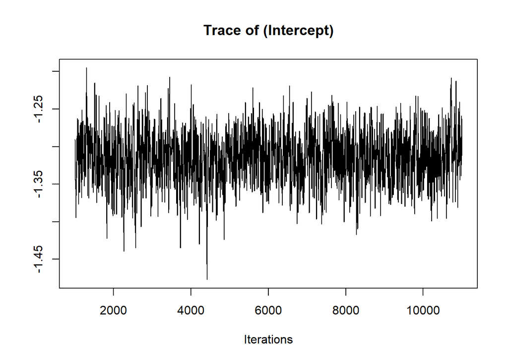

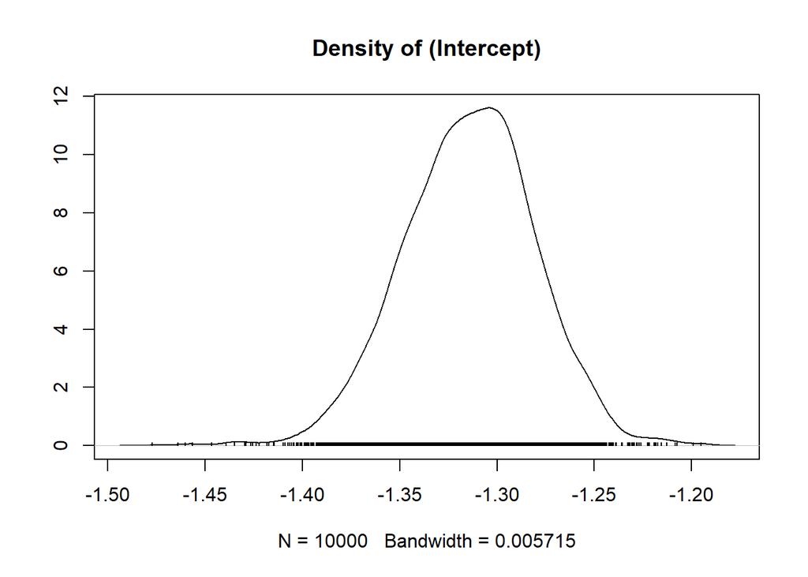

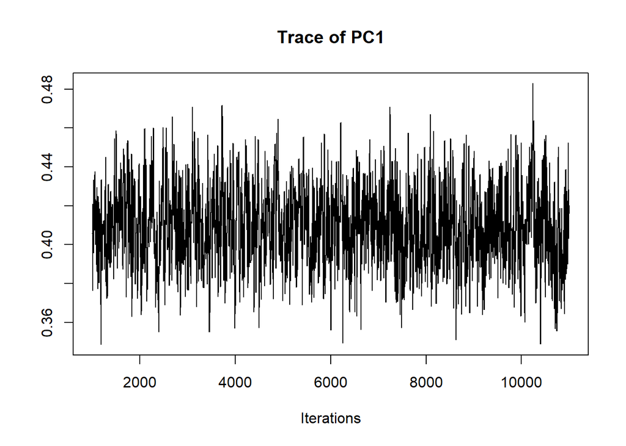

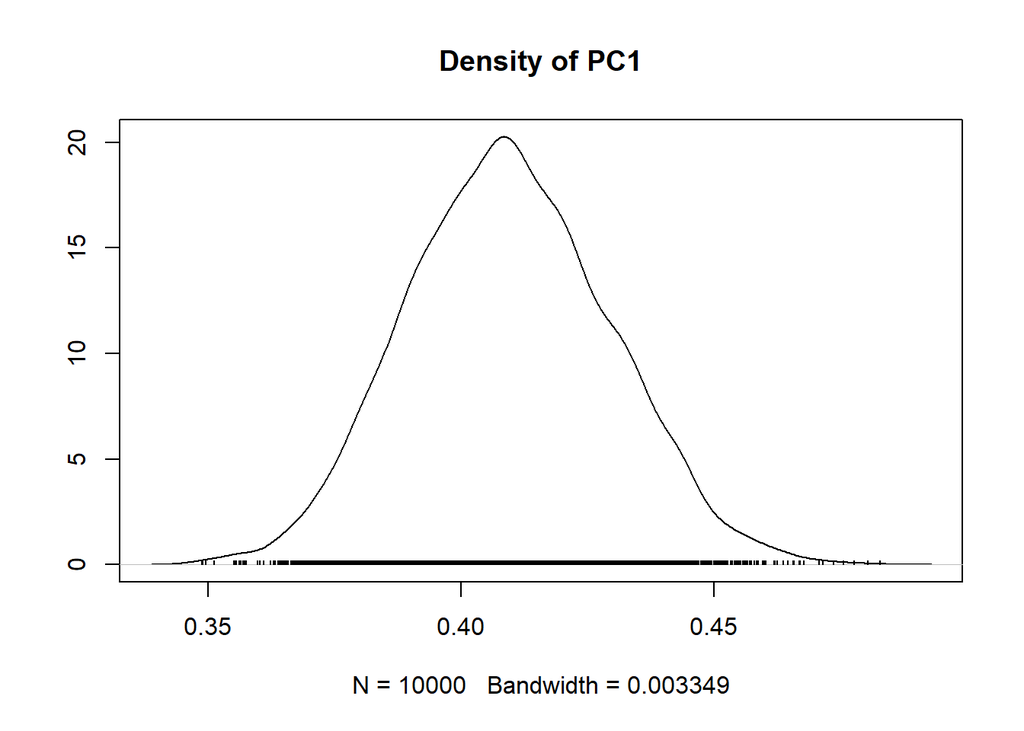

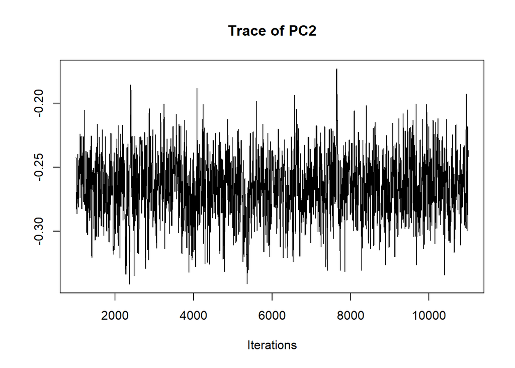

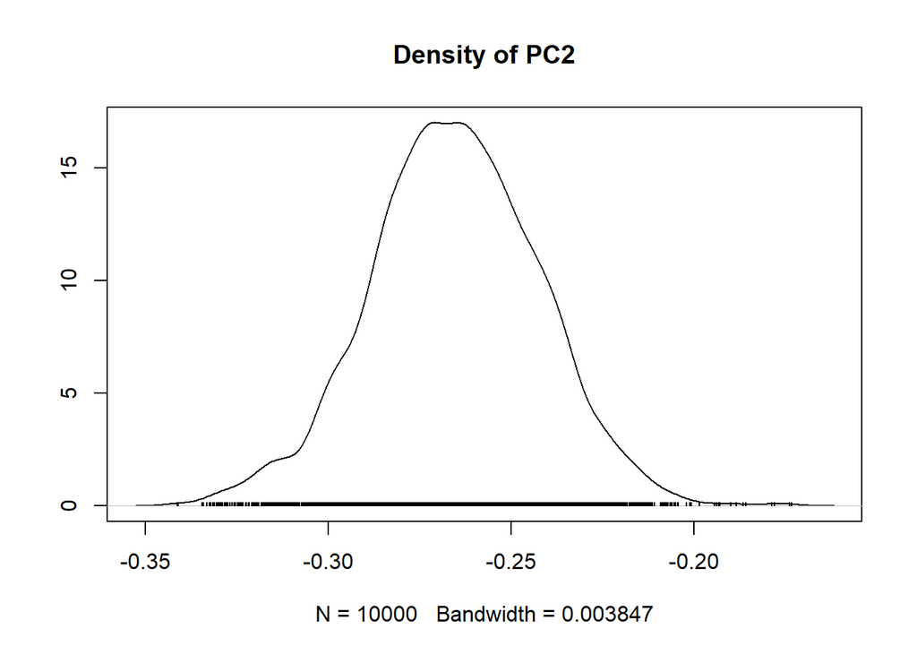

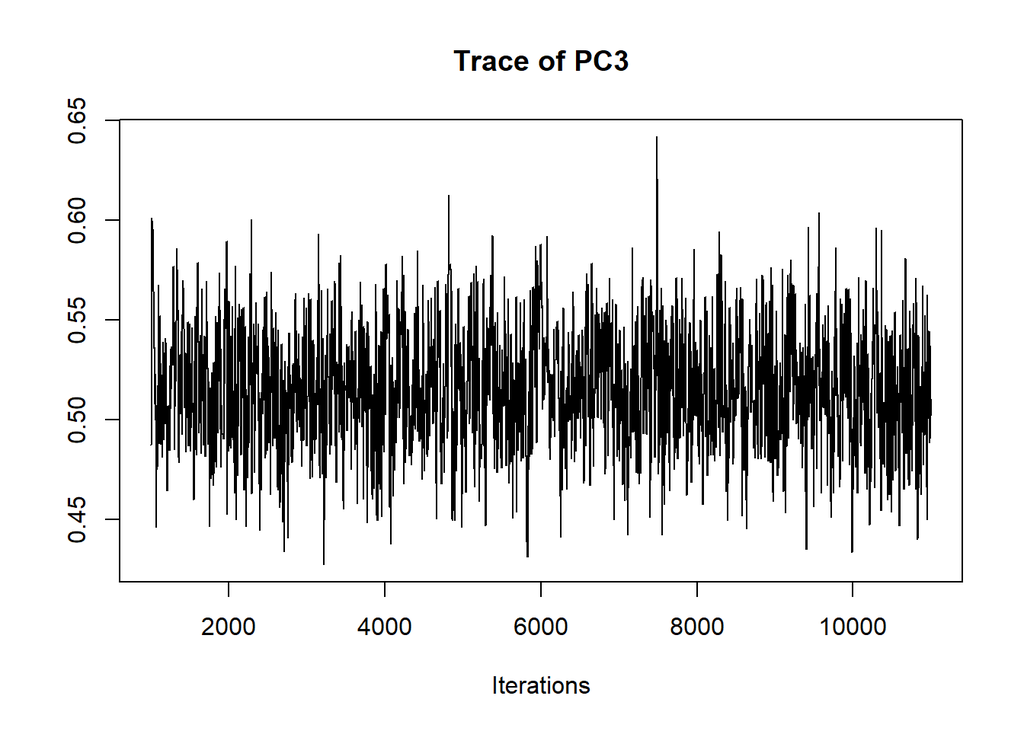

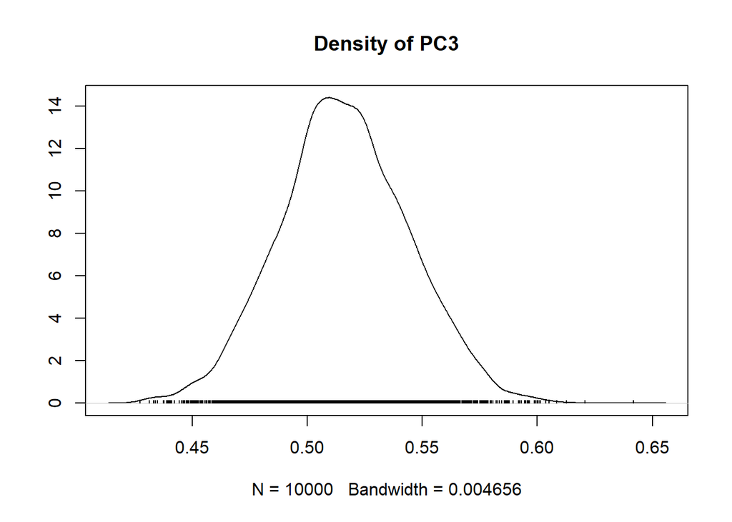

Model for the striker category:

```
##
## Iterations = 1001:11000
## Thinning interval = 1
## Number of chains = 1
## Sample size per chain = 10000
##
## 1. Empirical mean and standard deviation for each variable,
##    plus standard error of the mean:
##
##                Mean      SD  Naive SE Time-series SE
## (Intercept) -1.5141 0.04087 0.0004087      0.0014918
## PC1          0.7101 0.02558 0.0002558      0.0009377
## PC2         -0.1378 0.01982 0.0001982      0.0007245
## PC3         -0.7764 0.02813 0.0002813      0.0010146
##
## 2. Quantiles for each variable:
##
##                2.5%     25%     50%     75%    97.5%
## (Intercept) -1.5930 -1.5420 -1.5132 -1.4862 -1.43185
## PC1          0.6603  0.6928  0.7091  0.7264  0.76251
## PC2         -0.1773 -0.1508 -0.1375 -0.1248 -0.09863
## PC3         -0.8320 -0.7953 -0.7755 -0.7572 -0.72223
```

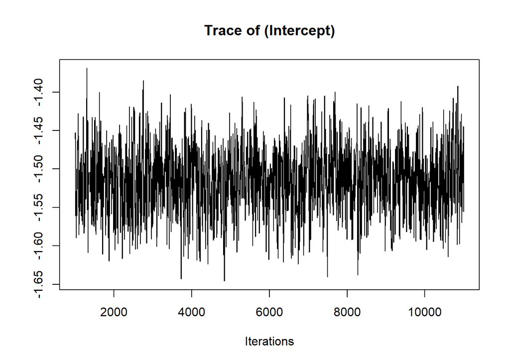

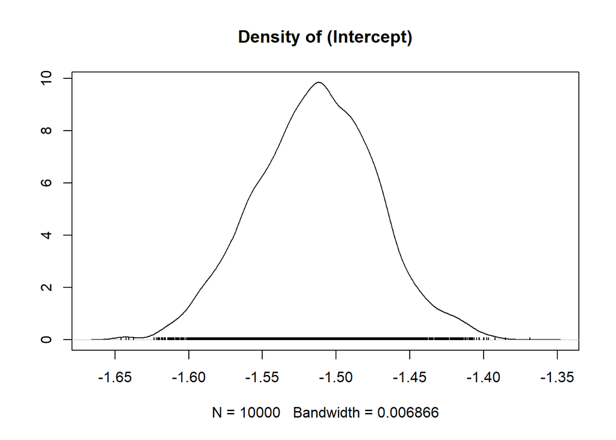

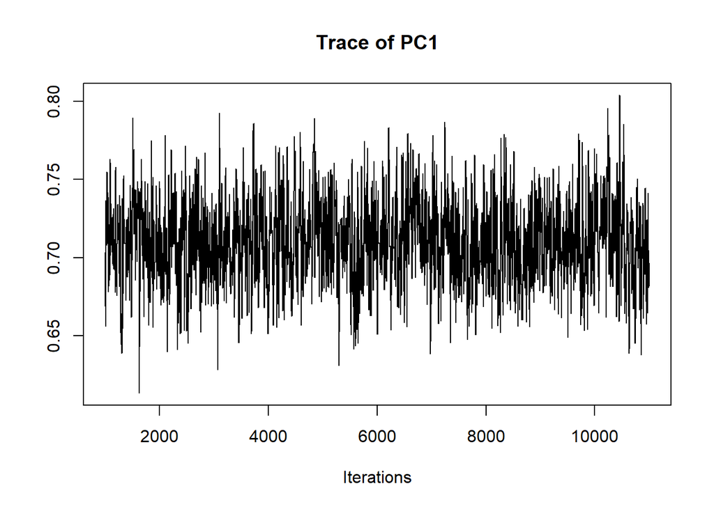

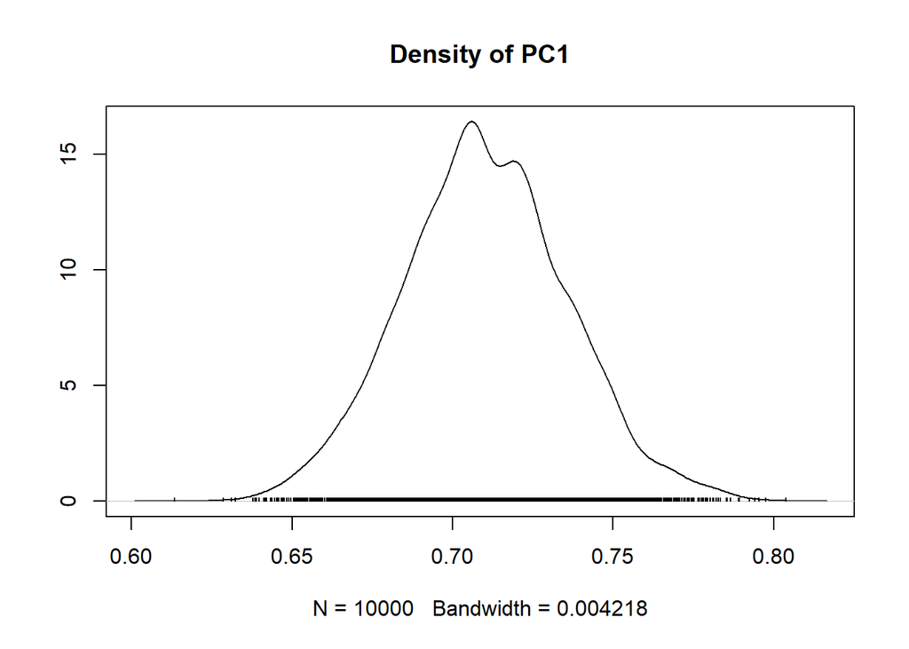

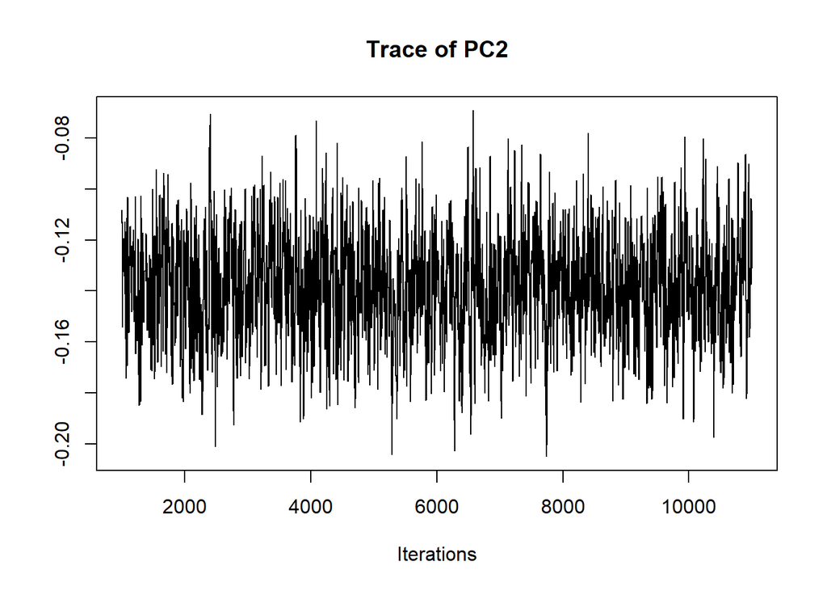

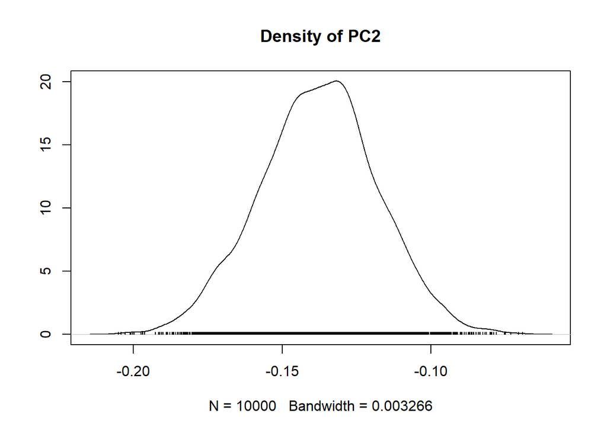

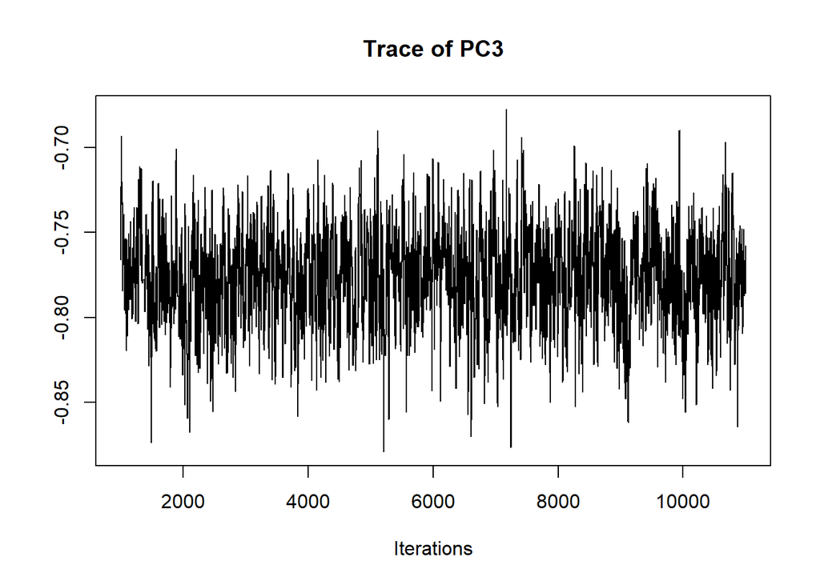

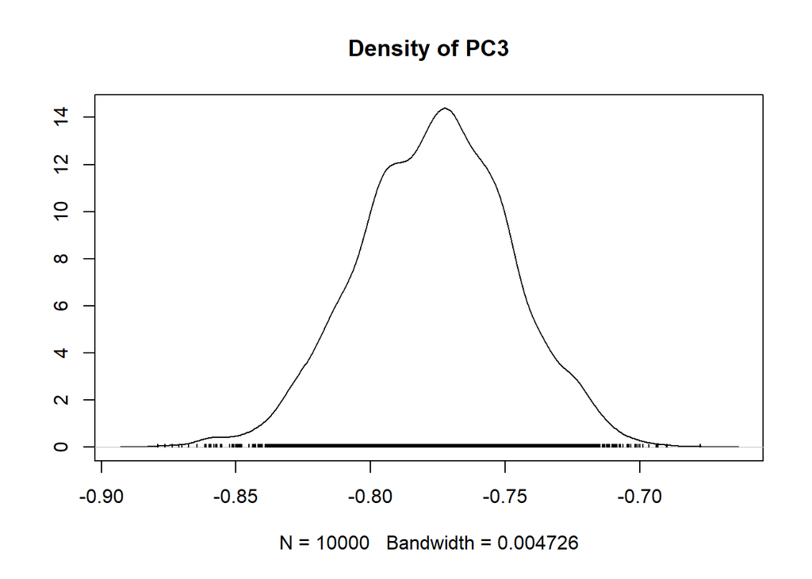

Computing the predictions on the test subset and obtaining the probabilities and posterior classification with the associated confusion matrix:

```
## Confusion Matrix and Statistics
##
##             Reference
## Prediction   Defender Goalkeeper Midfielder Striker
##   Defender        760          0         58       6
##   Goalkeeper        0        238          0      15
##   Midfielder      170          0        216     188
##   Striker           8         21         83     487
##
## Overall Statistics
##
##                Accuracy : 0.756
##                  95% CI : (0.7377, 0.7736)
##     No Information Rate : 0.4169
##     P-Value [Acc > NIR] : < 2.2e-16
##
##                   Kappa : 0.6571
##
##  Mcnemar's Test P-Value : NA
##
## Statistics by Class:
##
##                      Class: Defender Class: Goalkeeper Class: Midfielder
## Sensitivity                   0.8102            0.9189            0.6050
## Specificity                   0.9512            0.9925            0.8109
## Pos Pred Value                0.9223            0.9407            0.3763
## Neg Pred Value                0.8752            0.9895            0.9159
## Prevalence                    0.4169            0.1151            0.1587
## Detection Rate                0.3378            0.1058            0.0960
## Detection Prevalence          0.3662            0.1124            0.2551
## Balanced Accuracy             0.8807            0.9557            0.7080
##                      Class: Striker
## Sensitivity                  0.6997
## Specificity                  0.9279
## Pos Pred Value               0.8130
## Neg Pred Value               0.8734
## Prevalence                   0.3093
## Detection Rate               0.2164
## Detection Prevalence         0.2662
## Balanced Accuracy            0.8138
```

### 5.3 Probit regression

Suppose we have N independent binary random variables $y_{i}={0,1}$ where each $y_{i}$ comes from a Bernoulli distribution with probability of success $p_{i}$. We also assume that the success probability $p_{i}$ is related to a vector of covariates $x_{i}=(x_{i1},...,x_{1D})$. Then, we define the binary regression model as $p_{i}=g^{-1}(x_{i}\theta)$, where $\theta$ represents a $(D×1)$ column vector of regression coefficients, and $g^{-1}(·)$ is the link function. The probit model is obtained if we define $g^{-1}(·)=\phi(·)$, where $\phi(·)$ denotes the cumulative distribution function (cdf) of the standard normal distribution.

Model for the goalkeeper category, and plot of the probabilities according to the different values of PC1 and PC2:

[output not shown]

[output cut: 30 more lines]

[output not shown]

```
## Model:
##
## Iterations = 1001:11000
## Thinning interval = 1
## Number of chains = 1
## Sample size per chain = 10000
##
## 1. Empirical mean and standard deviation for each variable,
##    plus standard error of the mean:
##
##               Mean     SD Naive SE Time-series SE
## (Intercept) -7.902 0.4803 0.004803        0.25620
## PC1          1.072 0.1010 0.001010        0.02120
## PC2          1.872 0.1060 0.001060        0.02093
## PC3         -3.881 0.2596 0.002596        0.13045
##
## 2. Quantiles for each variable:
##
##                2.5%    25%    50%    75%  97.5%
## (Intercept) -8.7429 -8.366 -7.854 -7.522 -7.138
## PC1          0.8697  1.000  1.073  1.153  1.252
## PC2          1.6948  1.790  1.866  1.952  2.079
## PC3         -4.3227 -4.101 -3.859 -3.670 -3.458
##
## Next step: Use 'setx' method
```

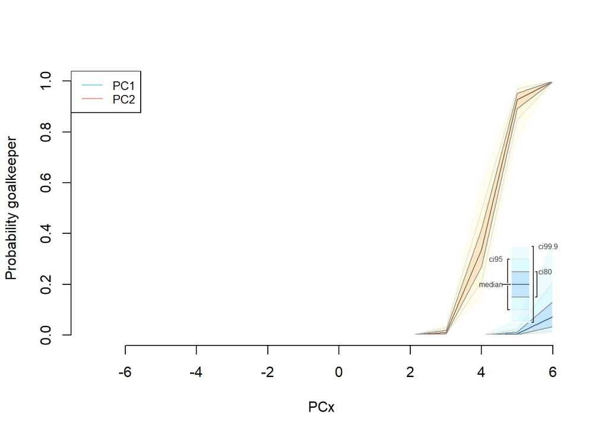

Model for the defender category, and plot of the probabilities according to the different values of PC1 and PC2:

[output not shown]

[output cut: 30 more lines]

[output not shown]

```
## Model:
##
## Iterations = 1001:11000
## Thinning interval = 1
## Number of chains = 1
## Sample size per chain = 10000
##
## 1. Empirical mean and standard deviation for each variable,
##    plus standard error of the mean:
##
##                Mean      SD  Naive SE Time-series SE
## (Intercept) -1.3146 0.05066 0.0005066       0.004739
## PC1         -0.9614 0.02550 0.0002550       0.001639
## PC2         -0.7144 0.02953 0.0002953       0.002118
## PC3          1.4428 0.04451 0.0004451       0.004258
##
## 2. Quantiles for each variable:
##
##                2.5%     25%     50%     75%   97.5%
## (Intercept) -1.4165 -1.3483 -1.3128 -1.2800 -1.2144
## PC1         -1.0137 -0.9784 -0.9606 -0.9433 -0.9147
## PC2         -0.7747 -0.7341 -0.7135 -0.6942 -0.6585
## PC3          1.3562  1.4135  1.4412  1.4727  1.5325
##
## Next step: Use 'setx' method
```

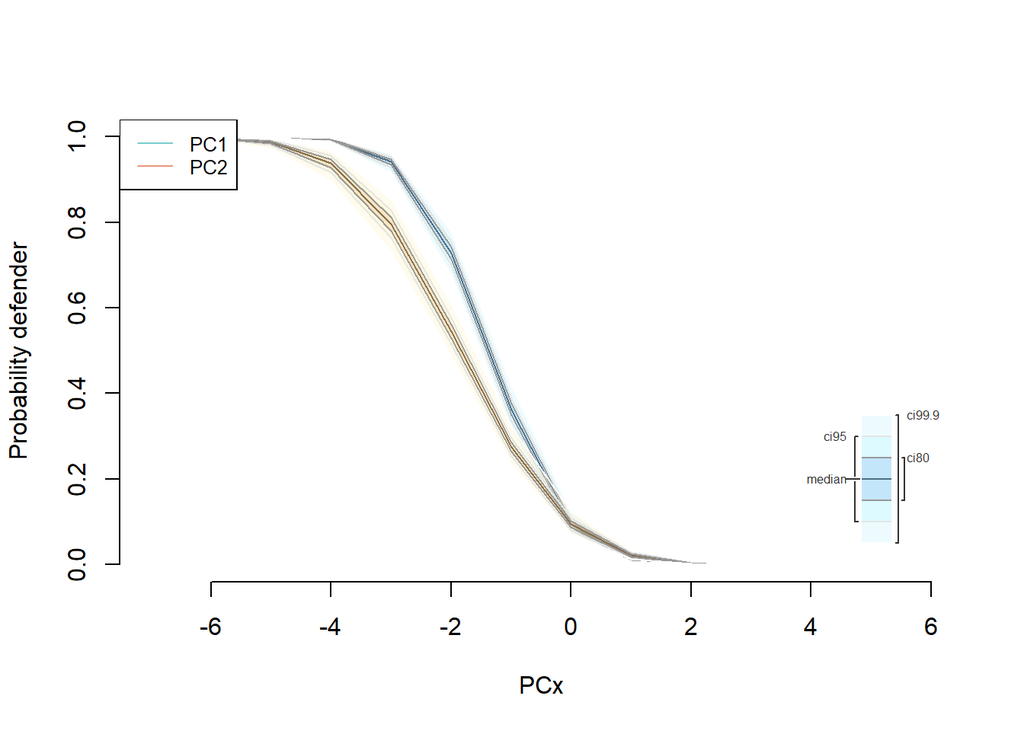

Model for the midfielder category, and plot of the probabilities according to the different values of PC1 and PC2:

[output not shown]

[output cut: 30 more lines]

[output not shown]

```
## Model:
##
## Iterations = 1001:11000
## Thinning interval = 1
## Number of chains = 1
## Sample size per chain = 10000
##
## 1. Empirical mean and standard deviation for each variable,
##    plus standard error of the mean:
##
##                Mean      SD  Naive SE Time-series SE
## (Intercept) -0.7965 0.01955 0.0001955      0.0004827
## PC1          0.2475 0.01149 0.0001149      0.0002530
## PC2         -0.1622 0.01375 0.0001375      0.0003278
## PC3          0.3120 0.01696 0.0001696      0.0004135
##
## 2. Quantiles for each variable:
##
##                2.5%     25%     50%     75%   97.5%
## (Intercept) -0.8346 -0.8095 -0.7967 -0.7832 -0.7584
## PC1          0.2253  0.2398  0.2474  0.2552  0.2702
## PC2         -0.1893 -0.1716 -0.1621 -0.1526 -0.1358
## PC3          0.2796  0.3002  0.3119  0.3235  0.3454
##
## Next step: Use 'setx' method
```

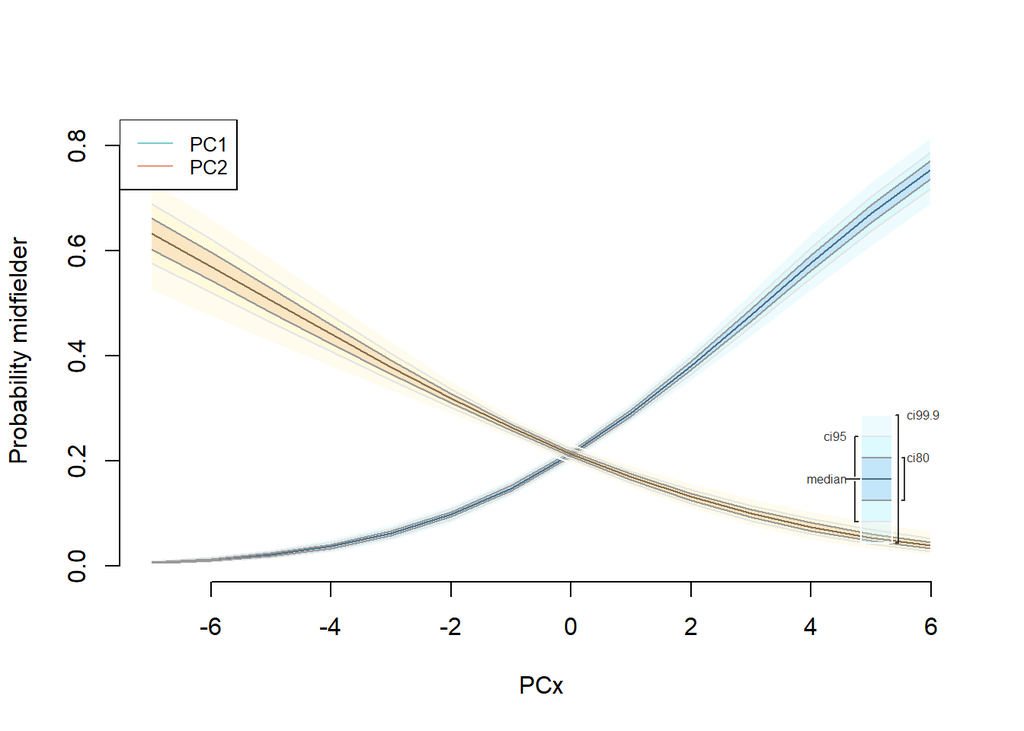

Model for the striker category, and plot of the probabilities according to the different values of PC1 and PC2:

[output not shown]

[output cut: 30 more lines]

[output not shown]

```
## Model:
##
## Iterations = 1001:11000
## Thinning interval = 1
## Number of chains = 1
## Sample size per chain = 10000
##
## 1. Empirical mean and standard deviation for each variable,
##    plus standard error of the mean:
##
##                 Mean      SD  Naive SE Time-series SE
## (Intercept) -0.89737 0.02234 0.0002234      0.0006001
## PC1          0.41230 0.01418 0.0001418      0.0004244
## PC2         -0.06925 0.01178 0.0001178      0.0002109
## PC3         -0.47069 0.01647 0.0001647      0.0003846
##
## 2. Quantiles for each variable:
##
##                 2.5%      25%      50%      75%    97.5%
## (Intercept) -0.94094 -0.91262 -0.89749 -0.88231 -0.85415
## PC1          0.38419  0.40283  0.41225  0.42208  0.43958
## PC2         -0.09181 -0.07731 -0.06917 -0.06119 -0.04669
## PC3         -0.50307 -0.48164 -0.47093 -0.45966 -0.43806
##
## Next step: Use 'setx' method
```

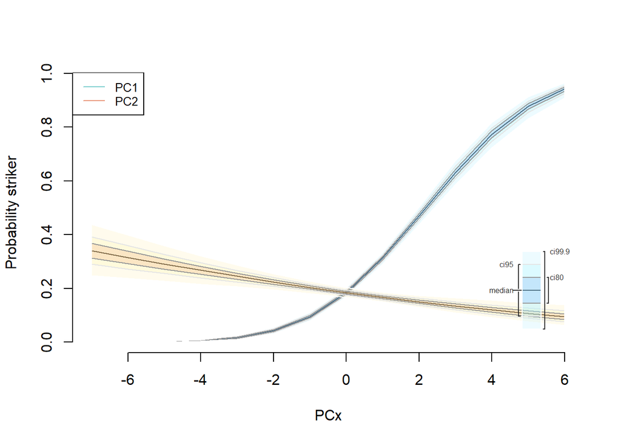

### 5.4. Methods based on the Bayes Theorem

#### 5.4.1. Naïve Bayes

In this case, in spite of using the same method which was studied in Bayesian Learning lectures, by taking into account the attribute nature, the approach of the method is different. This is in this way because, when it was exposed, the explained example counted with categorical variables, that is, if a concrete word appears or not in the tweet. Nevertheless, the presence of quantitative variables in FIFA problem means that Bayes Theorem can not be applied directly in the method from a frequentist approach. As an alternative of the studied approach in which the Bayes Theorem was used in order to determine conditional probabilities, in the case of quantitative attributes what is used is probability density functions(pdf). Therefore, pdf is estimated for every attribute and they will be used in the Naïve Bayes formula to obtain the corresponding probailities. With the aim of understanding the approach change in the Naïve Bayes method, the difference is explained in the following formulas:
$$Pr(y=j|x=x_{0})=\frac{Pr(x=x_{0}|y=j)Pr(y=j)}{\sum_{g=1}^{J}Pr(x=x_{0}|y=g)Pr(y=g)}$$
where j is the class whose probability is computed, and
$$Pr(y=j|x=x_{0})=\frac{\pi_{j}f_{j}(x_{0})}{\sum_{g=1}^{J}\pi_{g}f_{g}(x_{0})}$$
where $\pi_{j}$ is the probability (prior probability) that a randomly chosen observation of x comes from the j-th class, and $f_{j}(x_{0})$ is the joint density function of x in the j-th class evaluated at $x_{0}$. As it can be observed, both formulas are analogous but they are adapted to one of the mentioned cases. In addtition, there are some points which are important to consider. Naïve Bayes method belongs to methods known as “Methods based on the Bayes Theorem”. These methods use the previous formula in order to determine the probability of belonging to one class. Working with the standard approach of this type of methods, they use Multivariate Gaussian densities when try to estimate the density functions $f_{j}(x)$, in other words, the mean and the covariance matrices of each class density function. In particular, whereas other Methods based on the Bayes Theorem, such as Linear Discriminant Analysis or Quadratic Discriminant Analysis estimate mean vectors and covariance matrices, Naïve Bayes method considers that the predictors are independent what reduces substantially the computation cost. Further more, the independence assumptions is correct in this case considering that a previous Principal Component Analysis has been performed.

```r
fifa.bayes.fre <- naiveBayes(fifa.train.def[, 1:3], as.factor(fifa.train.def[, 4]))

fifa.test.predictions.fre <- predict(fifa.bayes.fre, newdata=fifa.test.def[,1:3])
confusionMatrix(fifa.test.predictions.fre, fifa.test.def$position)
```

```
## Confusion Matrix and Statistics
##
##             Reference
## Prediction   Defender Goalkeeper Midfielder Striker
##   Defender        652          0        127      12
##   Goalkeeper        0        233          0      36
##   Midfielder      158          0        274     103
##   Striker          14         20        173     448
##
## Overall Statistics
##
##                Accuracy : 0.7142
##                  95% CI : (0.6951, 0.7328)
##     No Information Rate : 0.3662
##     P-Value [Acc > NIR] : < 2.2e-16
##
##                   Kappa : 0.6029
##
##  Mcnemar's Test P-Value : NA
##
## Statistics by Class:
##
##                      Class: Defender Class: Goalkeeper Class: Midfielder
## Sensitivity                   0.7913            0.9209            0.4774
## Specificity                   0.9025            0.9820            0.8443
## Pos Pred Value                0.8243            0.8662            0.5121
## Neg Pred Value                0.8821            0.9899            0.8251
## Prevalence                    0.3662            0.1124            0.2551
## Detection Rate                0.2898            0.1036            0.1218
## Detection Prevalence          0.3516            0.1196            0.2378
## Balanced Accuracy             0.8469            0.9515            0.6608
##                      Class: Striker
## Sensitivity                  0.7479
## Specificity                  0.8746
## Pos Pred Value               0.6840
## Neg Pred Value               0.9053
## Prevalence                   0.2662
## Detection Rate               0.1991
## Detection Prevalence         0.2911
## Balanced Accuracy            0.8113
```

```r
fifa.bayes.laplacian <- naiveBayes(fifa.train.def[, 1:3], as.factor(fifa.train.def[, 4]), laplace=1)
fifa.test.predictions.laplacian <- predict(fifa.bayes.laplacian, newdata=fifa.test.def[,1:3])

confusionMatrix(fifa.test.predictions.laplacian, fifa.test.def$position)
```

```
## Confusion Matrix and Statistics
##
##             Reference
## Prediction   Defender Goalkeeper Midfielder Striker
##   Defender        652          0        127      12
##   Goalkeeper        0        233          0      36
##   Midfielder      158          0        274     103
##   Striker          14         20        173     448
##
## Overall Statistics
##
##                Accuracy : 0.7142
##                  95% CI : (0.6951, 0.7328)
##     No Information Rate : 0.3662
##     P-Value [Acc > NIR] : < 2.2e-16
##
##                   Kappa : 0.6029
##
##  Mcnemar's Test P-Value : NA
##
## Statistics by Class:
##
##                      Class: Defender Class: Goalkeeper Class: Midfielder
## Sensitivity                   0.7913            0.9209            0.4774
## Specificity                   0.9025            0.9820            0.8443
## Pos Pred Value                0.8243            0.8662            0.5121
## Neg Pred Value                0.8821            0.9899            0.8251
## Prevalence                    0.3662            0.1124            0.2551
## Detection Rate                0.2898            0.1036            0.1218
## Detection Prevalence          0.3516            0.1196            0.2378
## Balanced Accuracy             0.8469            0.9515            0.6608
##                      Class: Striker
## Sensitivity                  0.7479
## Specificity                  0.8746
## Pos Pred Value               0.6840
## Neg Pred Value               0.9053
## Prevalence                   0.2662
## Detection Rate               0.1991
## Detection Prevalence         0.2911
## Balanced Accuracy            0.8113
```

An alternative in order to be able to use a pure frequentist approach could be to distrize the quantitative variables. For example, by knowing that their values are between 0 and 100, these values could have been classified as high, medium and low depending regarding to a predefined criterion. Nevertheless, this method would be subjective.

#### 5.4.2. Linear Discriminant Analysis

Belonging to the groups of methods which are based on Bayes Theorem, its filosophy is very similar to Naïve Bayes method. In this way, LDA takes the assumption of having $f_{1}(x_{0}),...,f_{J}(x_{0})$ as multivariate Gaussians with different mean vectors $\mu_{1},...,\mu_{J}$ and common covariance matrix $\Sigma$. Therefore:

$$f_{j}(x_{})=(2\pi)^{-p/2}|\Sigma|^{-1/2}exp(-\frac{(x-\mu_{j})´\Sigma^{-1}(x-\mu_{j})}{2})$$

and

$$Pr(y=j|x=x_{0})=\frac{\pi_{j}exp(-\frac{(x-\mu_{j})´\Sigma^{-1}(x_{0}-\mu_{j})}{2})}{\sum_{g=1}^{J}\pi_{g}exp(-\frac{(x_{0}-\mu_{g})´\Sigma^{-1}(x_{0}-\mu_{g})}{2})}$$

Obviously, covariance matrix and mean vectors are estimated from the data. If the expression is observed, the denominator is the same for all $j$, so the classified class only depends on the prior distribution and the Mahalanobis distance between $x_{0}$ and $\mu_{j}$

```r
lda.fifa.train <- lda(formula=fifa.train.def$position~., data=fifa.train.def)
lda.fifa.pred <- predict(lda.fifa.train, newdata=fifa.test.def[,1:3])

confusionMatrix(fifa.test.def$position, lda.fifa.pred$class)
```

```
## Confusion Matrix and Statistics
##
##             Reference
## Prediction   Defender Goalkeeper Midfielder Striker
##   Defender        734          0         87       3
##   Goalkeeper        0        231          0      22
##   Midfielder      126          0        320     128
##   Striker           2         16         84     497
##
## Overall Statistics
##
##                Accuracy : 0.792
##                  95% CI : (0.7746, 0.8086)
##     No Information Rate : 0.3831
##     P-Value [Acc > NIR] : < 2.2e-16
##
##                   Kappa : 0.709
##
##  Mcnemar's Test P-Value : NA
##
## Statistics by Class:
##
##                      Class: Defender Class: Goalkeeper Class: Midfielder
## Sensitivity                   0.8515            0.9352            0.6517
## Specificity                   0.9352            0.9890            0.8556
## Pos Pred Value                0.8908            0.9130            0.5575
## Neg Pred Value                0.9102            0.9920            0.8980
## Prevalence                    0.3831            0.1098            0.2182
## Detection Rate                0.3262            0.1027            0.1422
## Detection Prevalence          0.3662            0.1124            0.2551
## Balanced Accuracy             0.8933            0.9621            0.7537
##                      Class: Striker
## Sensitivity                  0.7646
## Specificity                  0.9363
## Pos Pred Value               0.8297
## Neg Pred Value               0.9073
## Prevalence                   0.2889
## Detection Rate               0.2209
## Detection Prevalence         0.2662
## Balanced Accuracy            0.8504
```

In this case, the model accuracy tested in the test set is 79.20%, with a correct rate of 89.08 in defenders, 91.30% in goalkeepers, 55.75% in midfielders and 82.97%. Notice how, although the variables of PCA are not gaussian, the predictions are better than the Naïve model, while the most difficult position to estimate is midfielder again.

#### 5.4.3. Quadratic Discriminant Analysis

The assumptions are the same as the ones of Linear Discriminant Analysis. Nevertheless, there is an important modification in the moment of estimate the multivariate Gaussian distributions, considering that although the mean vectors are $\mu_{1},...,\mu_{J}$, now the covariance matrices are different between the functions, $\Sigma_{1},...,\Sigma_{J}$. Notice that, in spite of the change in the covatiance matrices, the denominator is the same for each probability.

```r
qda.fifa.train <- qda(fifa.train.def$position ~ ., data=fifa.train.def)
qda.fifa.pred <- predict(qda.fifa.train, newdata=fifa.test.def[,1:3])

confusionMatrix(qda.fifa.pred$class, fifa.test.def$position)
```

```
## Confusion Matrix and Statistics
##
##             Reference
## Prediction   Defender Goalkeeper Midfielder Striker
##   Defender        751          0        135       1
##   Goalkeeper        0        235          0       7
##   Midfielder       70          0        311      78
##   Striker           3         18        128     513
##
## Overall Statistics
##
##                Accuracy : 0.8044
##                  95% CI : (0.7874, 0.8207)
##     No Information Rate : 0.3662
##     P-Value [Acc > NIR] : < 2.2e-16
##
##                   Kappa : 0.7258
##
##  Mcnemar's Test P-Value : NA
##
## Statistics by Class:
##
##                      Class: Defender Class: Goalkeeper Class: Midfielder
## Sensitivity                   0.9114            0.9289            0.5418
## Specificity                   0.9046            0.9965            0.9117
## Pos Pred Value                0.8467            0.9711            0.6776
## Neg Pred Value                0.9464            0.9910            0.8532
## Prevalence                    0.3662            0.1124            0.2551
## Detection Rate                0.3338            0.1044            0.1382
## Detection Prevalence          0.3942            0.1076            0.2040
## Balanced Accuracy             0.9080            0.9627            0.7268
##                      Class: Striker
## Sensitivity                  0.8564
## Specificity                  0.9098
## Pos Pred Value               0.7749
## Neg Pred Value               0.9458
## Prevalence                   0.2662
## Detection Rate               0.2280
## Detection Prevalence         0.2942
## Balanced Accuracy            0.8831
```

# 6. Conclusions

Throughout the development of this work, a dataset with thousands of male football players characterized by attributes such as their dribbling or shooting abilities. In addition, they are labelled with the position where they usually play: goalkeeper, defender, midfielder or striker. The goal of this study is to first, explore the dataset, understand its main features through a descriptive analysis and an unsupervised classification; and then to try to classify each football player by its position.

From the descriptive analysis one should remark how most features do not clearly discriminate among the four classes (except for goalkeeper ability, of course); their distributions are mostly overlapped. To reduce the number of features while still capturing most of the information, a Principal Component Analysis was performed. It allowed to maintain information from most of the features, while reducing the computational time and power required, which is a must since the whole code takes longer than an hour to run on our personal laptops. 3 Principal Components were chosen, and they explain most of the variance. The first one agglutinates information about defence, physical conditions, weight and height; the second focuses mainly on goalkeeper abilities and the third one on defensive and physical abilities.

With the new feature space, an unsupervised analysis (finite mixture of gaussians) was performed using 2, 3 and 4 distributions. What was found is that, despite specifying 3 or 4 distributions, they appear to overlap in univariate and bivariate plots. The Principal Component in which less overlapped distributions were observed was the third one, which groups info about defense and physical abilities. In addition, goalkeepers and strikers were sometimes found in the same clusters (their height and weight is similar and that is what the first PC is talking about). Defenders are in most cases identified well, but this does not happen for midfielders. It is the most heterogeneous group, with players of very different profiles and they are sometimes confused with strikers and defenders. These conclusions advance some of the obstacles that classification algorithm faced in the next phases of this project: midfielder is not a sufficiently narrow label and therefore it is complicated to classify them; when confused, goalkeepers are confused with strikers; and defenders and strikers are clearly two different types of players.

For classification, different algorithms were tested: Gaussian Processes, Logistic Regression, Probit Regression, Naive Bayes, Linear Discriminant Analysis and Quadratic Discriminant Analysis. For some of them, such as Logistic Regression, both a frequentist and a bayesian approach were tested, and their results compared. As a general remark, very similar accuracies, sensitivities and sensibilities were obtained and the frequentist approach was faster to compute. The main advantage of bayesian methods, their built-in uncertainty treatment, was not a vital advantage for these final metrics. However, it could make a difference when using these methods for a final product implementation, where the uncertainty of the results needs to be taken into consideration very seriously.

Gaussian Processes, Logistic and Probit Regression share the same approach towards classification. The three of them are originally pure regression algorithms, but by using a link function they may be used for classification, as it is done in this project. As a general remark, turns out that Gaussian Processes outperform the other two algorithms: they are better at correctly classifying a goalkeeper as goalkeeper and at correctly saying that another type of player is not a goalkeeper (sensitivity and sensibility are higher). And that for all classes. The fact that the second PC focuses on goalkeeper abilities is clearly observed in the line plots of the Probit Regression. In them, it is undoubtfully observed how increasing the value of PC2, the probability of classifying an instance as goalkeeper increases dramatically. Interestingly, the probability of classifying an instance as midfielder or striker increasing when the value of PC1 increases, but the probability of being a defender decreases. Recall that this first component was negatively influenced by defensive abilities.

The other three methods (Naive Bayes, Linear Discriminant Analysis and Quadratic Discriminant Analysis) are pure Bayesian methods (perhaps Gaussian Processes should also be put in this category), not as Logistic and Probit Regression, which may be approached from a bayesian or from a frequentist perspective. LDA and QDA assume gaussianity and despite the Principal Components are not gaussian, the algorithms have been tried. From the three of them, QDA has the highest metrics (80% of accuracy, for instance). This may be due that, despite it is assuming gaussianity, since it allows for different covariance matrices for each estimated function, it has more flexibility to adapt to the Fifa dataset used in this report.

As a general remark from all classification algorithms, it is easier to classify goalkeepers and with high confidence (there is a whole feature that measures goalkeeper abilities and it is very significative in one of the principal components). Also, midfielders are the most complicated to classify, since they are very heterogeneous. Finally, goalkeepers are sometimes confused with strikers (when they are misclassified, which does not happen often) and defenders with midfielders. All these limitations were anticipated by the unsupervised analysis.